# An Introduction to Generalised Linear Models (4th edition)

```r
#cumulative hazard function
data |> mutate(logH=log(-log(S)),
               logY=log(time))
```

```
##     n d time treatment         s          S        logH      logY
## 1  21 0    0   control 1.0000000 1.00000000        -Inf      -Inf
## 2  21 2    1   control 0.9047619 0.90476190 -2.30175086 0.0000000
## 3  19 2    2   control 0.8947368 0.80952381 -1.55443332 0.6931472
## 4  17 1    3   control 0.9411765 0.76190476 -1.30219694 1.0986123
## 5  16 2    4   control 0.8750000 0.66666667 -0.90272046 1.3862944
## 6  14 2    5   control 0.8571429 0.57142857 -0.58050482 1.6094379
## 7  12 4    8   control 0.6666667 0.38095238 -0.03554335 2.0794415
## 8   8 2   11   control 0.7500000 0.28571429  0.22535149 2.3978953
## 9   6 2   12   control 0.6666667 0.19047619  0.50574961 2.4849066
## 10  4 1   15   control 0.7500000 0.14285714  0.66572981 2.7080502
## 11  3 1   17   control 0.6666667 0.09523810  0.85500037 2.8332133
## 12  2 1   22   control 0.5000000 0.04761905  1.11334405 3.0910425
## 13  1 1   23   control 0.0000000 0.00000000         Inf 3.1354942
## 14 21 0    0 treatment 1.0000000 1.00000000        -Inf      -Inf
## 15 21 3    6 treatment 0.8571429 0.85714286 -1.86982471 1.7917595
## 16 17 1    7 treatment 0.9411765 0.80672269 -1.53816291 1.9459101
## 17 15 1   10 treatment 0.9333333 0.75294118 -1.25959767 2.3025851
## 18 12 1   13 treatment 0.9166667 0.69019608 -0.99214760 2.5649494
## 19 11 1   16 treatment 0.9090909 0.62745098 -0.76337711 2.7725887
## 20  7 1   22 treatment 0.8571429 0.53781513 -0.47764812 3.0910425
## 21  6 1   23 treatment 0.8333333 0.44817927 -0.21994621 3.1354942
```

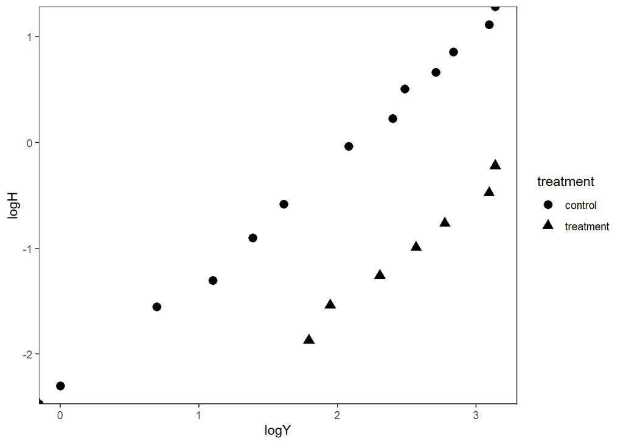

```r
data |> mutate(logH=log(-log(S)),
               logY=log(time)) |> ggplot(aes(x=logY, y=logH)) + geom_point(aes(shape = treatment), size=3) +
  theme_bw() + theme(
  # Hide panel borders and remove grid lines
  #panel.border = element_line(colour = "black"),
  panel.grid.major = element_blank(),
  panel.grid.minor = element_blank(),
  # Change axis line
  #axis.line = element_line(colour = "black")
)
```

```r
remission
```

```
## # A tibble: 42 × 3
##     time group censored
##    <dbl> <chr>    <dbl>
##  1     1 C            0
##  2     1 C            0
##  3     2 C            0
##  4     2 C            0
##  5     3 C            0
##  6     4 C            0
##  7     4 C            0
##  8     5 C            0
##  9     5 C            0
## 10     8 C            0
## 11     8 C            0
## 12     8 C            0
## 13     8 C            0
## 14    11 C            0
## 15    11 C            0
## 16    12 C            0
## 17    12 C            0
## 18    15 C            0
## 19    17 C            0
## 20    22 C            0
## 21    23 C            0
## 22     6 T            0
## 23     6 T            0
## 24     6 T            0
## 25     6 T            1
## # ℹ 17 more rows
```

```r
#the exponential model can be fitted:
res.gehanexp<-glm(censored==0~group + offset(log(time)), family=poisson(),
                  data=remission)
summary(res.gehanexp)
```

```
##
## Call:
## glm(formula = censored == 0 ~ group + offset(log(time)), family = poisson(),
##     data = remission)
##
## Coefficients:
##             Estimate Std. Error z value Pr(>|z|)
## (Intercept)  -2.1595     0.2182  -9.896  < 2e-16 ***
## groupT       -1.5266     0.3984  -3.832 0.000127 ***
## ---
## Signif. codes:  0 '***' 0.001 '**' 0.01 '*' 0.05 '.' 0.1 ' ' 1
##
## (Dispersion parameter for poisson family taken to be 1)
##
##     Null deviance: 54.503  on 41  degrees of freedom
## Residual deviance: 38.017  on 40  degrees of freedom
## AIC: 102.02
##
## Number of Fisher Scoring iterations: 6
```

```r
#AIC
AIC(res.gehanexp)
```

```
## [1] 102.0173
```

```r
-2* logLik(res.gehanexp)+2*2
```

```
## 'log Lik.' 102.0173 (df=2)
```

```r
log(remission$time)
```

```
##  [1] 0.0000000 0.0000000 0.6931472 0.6931472 1.0986123 1.3862944 1.3862944
##  [8] 1.6094379 1.6094379 2.0794415 2.0794415 2.0794415 2.0794415 2.3978953
## [15] 2.3978953 2.4849066 2.4849066 2.7080502 2.8332133 3.0910425 3.1354942
## [22] 1.7917595 1.7917595 1.7917595 1.7917595 1.9459101 2.1972246 2.3025851
## [29] 2.3025851 2.3978953 2.5649494 2.7725887 2.8332133 2.9444390 2.9957323
## [36] 3.0910425 3.1354942 3.2188758 3.4657359 3.4657359 3.5263605 3.5553481
```

```r
offset(log(remission$time))
```

```
##  [1] 0.0000000 0.0000000 0.6931472 0.6931472 1.0986123 1.3862944 1.3862944
##  [8] 1.6094379 1.6094379 2.0794415 2.0794415 2.0794415 2.0794415 2.3978953
## [15] 2.3978953 2.4849066 2.4849066 2.7080502 2.8332133 3.0910425 3.1354942
## [22] 1.7917595 1.7917595 1.7917595 1.7917595 1.9459101 2.1972246 2.3025851
## [29] 2.3025851 2.3978953 2.5649494 2.7725887 2.8332133 2.9444390 2.9957323
## [36] 3.0910425 3.1354942 3.2188758 3.4657359 3.4657359 3.5263605 3.5553481
```

```r
mu <- res.gehanexp$fitted.values
y <- remission$time
m <- sum(remission$censored == 0)
delta <- (remission$censored * -1)+1
#lambda_hat
m/sum((mu-delta)*log(y), na.rm = TRUE)
```

```
## [1] 1.631587
```

```r
library(survival)
Surv(remission$time,remission$censored==0)
```

```
##  [1]  1   1   2   2   3   4   4   5   5   8   8   8   8  11  11  12  12  15  17
## [20] 22  23   6   6   6   6+  7   9+ 10  10+ 11+ 13  16  17+ 19+ 20+ 22  23  25+
## [39] 32+ 32+ 34+ 35+
```

```r
res.gehan<-survreg(Surv(time,censored==0)~group, dist="exponential", data=remission)
summary(res.gehan)
```

```
##
## Call:
## survreg(formula = Surv(time, censored == 0) ~ group, data = remission,
##     dist = "exponential")
##             Value Std. Error    z       p
## (Intercept) 2.159      0.218 9.90 < 2e-16
## groupT      1.527      0.398 3.83 0.00013
##
## Scale fixed at 1
##
## Exponential distribution
## Loglik(model)= -108.5   Loglik(intercept only)= -116.8
##  Chisq= 16.49 on 1 degrees of freedom, p= 4.9e-05
## Number of Newton-Raphson Iterations: 4
## n= 42
```

```r
#AIC
AIC(res.gehan)
```

```
## [1] 221.0481
```

```r
-2* logLik(res.gehan)+2*2
```

```
## 'log Lik.' 221.0481 (df=2)
```

```r
res.gehan.weibull <-survreg(Surv(time,censored==0)~group,dist="weibull", data=remission)
summary(res.gehan.weibull)
```

```
##
## Call:
## survreg(formula = Surv(time, censored == 0) ~ group, data = remission,
##     dist = "weibull")
##              Value Std. Error     z       p
## (Intercept)  2.248      0.166 13.55 < 2e-16
## groupT       1.267      0.311  4.08 4.5e-05
## Log(scale)  -0.312      0.147 -2.12   0.034
##
## Scale= 0.732
##
## Weibull distribution
## Loglik(model)= -106.6   Loglik(intercept only)= -116.4
##  Chisq= 19.65 on 1 degrees of freedom, p= 9.3e-06
## Number of Newton-Raphson Iterations: 5
## n= 42
```

```r
res.gehan.weibull$scale
```

```
## [1] 0.7321944
```

```r
AIC(res.gehan.weibull)
```

```
## [1] 219.159
```

```r
#leukemia_survival <- read.csv("leukemia_survival.csv", sep=" ", header = FALSE)
#colnames(leukemia_survival) <- c("Survival.time","White.blood.cell","Survival.time","White.blood.cell")
#leukemia_survival2 <- rbind(leukemia_survival[,1:2], leukemia_survival[,3:4])
#leukemia_survival2$AG <- c(rep("positive", 17), rep("negative", 17))
#leukemia_survival2
```

```r
#Table10.4
leukemia_survival <- structure(list(Survival.time = c(65L, 156L, 100L, 134L, 16L,
108L, 121L, 4L, 39L, 143L, 56L, 26L, 22L, 1L, 1L, 5L, 65L, 56L,
65L, 17L, 7L, 16L, 22L, 3L, 4L, 2L, 3L, 8L, 4L, 3L, 30L, 4L,
43L, NA), White.blood.cell = c(2.3, 0.75, 4.3, 2.6, 6, 10.5,
10, 17, 5.4, 7, 9.4, 32, 35, 100, 100, 52, 100, 4.4, 3, 4, 1.5,
9, 5.3, 10, 19, 27, 28, 31, 26, 21, 79, 100, 100, NA), AG = c("positive",
"positive", "positive", "positive", "positive", "positive", "positive",
"positive", "positive", "positive", "positive", "positive", "positive",
"positive", "positive", "positive", "positive", "negative", "negative",
"negative", "negative", "negative", "negative", "negative", "negative",
"negative", "negative", "negative", "negative", "negative", "negative",
"negative", "negative", "negative")), row.names = c(NA, -34L), class = "data.frame")
leukemia_survival
```

```
##    Survival.time White.blood.cell       AG
## 1             65             2.30 positive
## 2            156             0.75 positive
## 3            100             4.30 positive
## 4            134             2.60 positive
## 5             16             6.00 positive
## 6            108            10.50 positive
## 7            121            10.00 positive
## 8              4            17.00 positive
## 9             39             5.40 positive
## 10           143             7.00 positive
## 11            56             9.40 positive
## 12            26            32.00 positive
## 13            22            35.00 positive
## 14             1           100.00 positive
```

[output cut: 20 more lines]

```r
#Exercises 10.1
survival_AG_positive <- data.frame(
  n=c(17,17,15,14,13,12,11,10,9,8,6,5,4,3,2,1),
  d=c(0,2,1,1,1,1,1,1,1,2,1,1,1,1,1,1) #"0to1", "1to4", "4to5", "5to16", "16to22", "22to26","26to39","39to56", "56to65","65to100","100to108","108to121","121to134","134to143","143to156","156to..."
) |> mutate(time = c(0, unique(sort(leukemia_survival[leukemia_survival$AG == "positive",]$Survival.time))),
            AG = rep("positive", 16),
            s=(n-d)/n,
            S=cumprod(s))
survival_AG_positive
```

```
##     n d time       AG         s          S
## 1  17 0    0 positive 1.0000000 1.00000000
## 2  17 2    1 positive 0.8823529 0.88235294
## 3  15 1    4 positive 0.9333333 0.82352941
## 4  14 1    5 positive 0.9285714 0.76470588
## 5  13 1   16 positive 0.9230769 0.70588235
## 6  12 1   22 positive 0.9166667 0.64705882
## 7  11 1   26 positive 0.9090909 0.58823529
## 8  10 1   39 positive 0.9000000 0.52941176
## 9   9 1   56 positive 0.8888889 0.47058824
## 10  8 2   65 positive 0.7500000 0.35294118
## 11  6 1  100 positive 0.8333333 0.29411765
## 12  5 1  108 positive 0.8000000 0.23529412
## 13  4 1  121 positive 0.7500000 0.17647059
## 14  3 1  134 positive 0.6666667 0.11764706
## 15  2 1  143 positive 0.5000000 0.05882353
## 16  1 1  156 positive 0.0000000 0.00000000
```

```r
survival_AG_negative <- data.frame(
  n=c(16,16,15,12,9,8,7,6,5,4,3,2,1),
  d=c(0,1,3,3,1,1,1,1,1,1,1,1,1) #"0to2", 2to3", "3to4", "4to7", "7to8", "8to16", "16to17","17to22","22to30", "30to43","43to56","56to65","65to..."
) |> mutate(time = c(0, unique(sort(leukemia_survival[leukemia_survival$AG == "negative",]$Survival.time))),
            AG = rep("negative", 13),
            s=(n-d)/n,
            S=cumprod(s))
survival_AG_negative
```

```
##     n d time       AG         s      S
## 1  16 0    0 negative 1.0000000 1.0000
## 2  16 1    2 negative 0.9375000 0.9375
## 3  15 3    3 negative 0.8000000 0.7500
## 4  12 3    4 negative 0.7500000 0.5625
## 5   9 1    7 negative 0.8888889 0.5000
## 6   8 1    8 negative 0.8750000 0.4375
## 7   7 1   16 negative 0.8571429 0.3750
## 8   6 1   17 negative 0.8333333 0.3125
## 9   5 1   22 negative 0.8000000 0.2500
## 10  4 1   30 negative 0.7500000 0.1875
## 11  3 1   43 negative 0.6666667 0.1250
## 12  2 1   56 negative 0.5000000 0.0625
## 13  1 1   65 negative 0.0000000 0.0000
```

```r
survival_AG <- rbind(survival_AG_positive, survival_AG_negative)
survival_AG
```

```
##     n d time       AG         s          S
## 1  17 0    0 positive 1.0000000 1.00000000
## 2  17 2    1 positive 0.8823529 0.88235294
## 3  15 1    4 positive 0.9333333 0.82352941
## 4  14 1    5 positive 0.9285714 0.76470588
## 5  13 1   16 positive 0.9230769 0.70588235
## 6  12 1   22 positive 0.9166667 0.64705882
## 7  11 1   26 positive 0.9090909 0.58823529
## 8  10 1   39 positive 0.9000000 0.52941176
## 9   9 1   56 positive 0.8888889 0.47058824
## 10  8 2   65 positive 0.7500000 0.35294118
## 11  6 1  100 positive 0.8333333 0.29411765
## 12  5 1  108 positive 0.8000000 0.23529412
## 13  4 1  121 positive 0.7500000 0.17647059
## 14  3 1  134 positive 0.6666667 0.11764706
## 15  2 1  143 positive 0.5000000 0.05882353
## 16  1 1  156 positive 0.0000000 0.00000000
## 17 16 0    0 negative 1.0000000 1.00000000
## 18 16 1    2 negative 0.9375000 0.93750000
## 19 15 3    3 negative 0.8000000 0.75000000
## 20 12 3    4 negative 0.7500000 0.56250000
## 21  9 1    7 negative 0.8888889 0.50000000
## 22  8 1    8 negative 0.8750000 0.43750000
## 23  7 1   16 negative 0.8571429 0.37500000
## 24  6 1   17 negative 0.8333333 0.31250000
## 25  5 1   22 negative 0.8000000 0.25000000
## 26  4 1   30 negative 0.7500000 0.18750000
## 27  3 1   43 negative 0.6666667 0.12500000
## 28  2 1   56 negative 0.5000000 0.06250000
## 29  1 1   65 negative 0.0000000 0.00000000
```

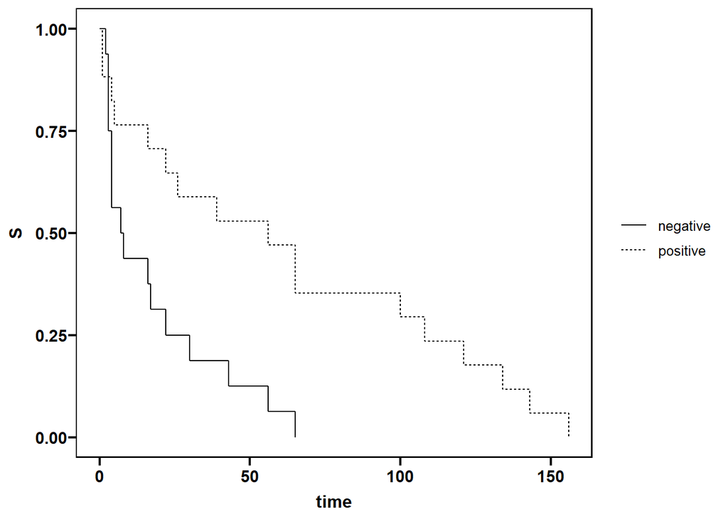

```r
survival_AG |> ggplot(aes(x=time, y=S)) + geom_step(aes(linetype = AG)) + theme_bw() + theme(
  # Hide panel borders and remove grid lines
  #panel.border = element_line(colour = "black"),
  panel.grid.major = element_blank(),
  panel.grid.minor = element_blank(),
  # Change axis line
  #axis.line = element_line(colour = "black")
) + theme_prism(border = TRUE,
              palette = "black_and_white",
              base_size = 12)
```

```r
#cumulative hazard function
survival_AG |> mutate(logH=log(-log(S)),
               logY=log(time))
```

```
##     n d time       AG         s          S        logH      logY
## 1  17 0    0 positive 1.0000000 1.00000000        -Inf      -Inf
## 2  17 2    1 positive 0.8823529 0.88235294 -2.07813725 0.0000000
## 3  15 1    4 positive 0.9333333 0.82352941 -1.63909324 1.3862944
## 4  14 1    5 positive 0.9285714 0.76470588 -1.31578376 1.6094379
## 5  13 1   16 positive 0.9230769 0.70588235 -1.05467188 2.7725887
## 6  12 1   22 positive 0.9166667 0.64705882 -0.83167832 3.0910425
## 7  11 1   26 positive 0.9090909 0.58823529 -0.63369360 3.2580965
## 8  10 1   39 positive 0.9000000 0.52941176 -0.45257438 3.6635616
## 9   9 1   56 positive 0.8888889 0.47058824 -0.28266561 4.0253517
## 10  8 2   65 positive 0.7500000 0.35294118  0.04061769 4.1743873
## 11  6 1  100 positive 0.8333333 0.29411765  0.20194070 4.6051702
## 12  5 1  108 positive 0.8000000 0.23529412  0.36943646 4.6821312
## 13  4 1  121 positive 0.7500000 0.17647059  0.55077745 4.7957905
## 14  3 1  134 positive 0.6666667 0.11764706  0.76083675 4.8978398
## 15  2 1  143 positive 0.5000000 0.05882353  1.04141152 4.9628446
## 16  1 1  156 positive 0.0000000 0.00000000         Inf 5.0498560
## 17 16 0    0 negative 1.0000000 1.00000000        -Inf      -Inf
## 18 16 1    2 negative 0.9375000 0.93750000 -2.74049301 0.6931472
## 19 15 3    3 negative 0.8000000 0.75000000 -1.24589932 1.0986123
## 20 12 3    4 negative 0.7500000 0.56250000 -0.55275214 1.3862944
## 21  9 1    7 negative 0.8888889 0.50000000 -0.36651292 1.9459101
## 22  8 1    8 negative 0.8750000 0.43750000 -0.19033933 2.0794415
## 23  7 1   16 negative 0.8571429 0.37500000 -0.01935689 2.7725887
## 24  6 1   17 negative 0.8333333 0.31250000  0.15113254 2.8332133
## 25  5 1   22 negative 0.8000000 0.25000000  0.32663426 3.0910425
## 26  4 1   30 negative 0.7500000 0.18750000  0.51520189 3.4011974
## 27  3 1   43 negative 0.6666667 0.12500000  0.73209937 3.7612001
## 28  2 1   56 negative 0.5000000 0.06250000  1.01978144 4.0253517
## 29  1 1   65 negative 0.0000000 0.00000000         Inf 4.1743873
```

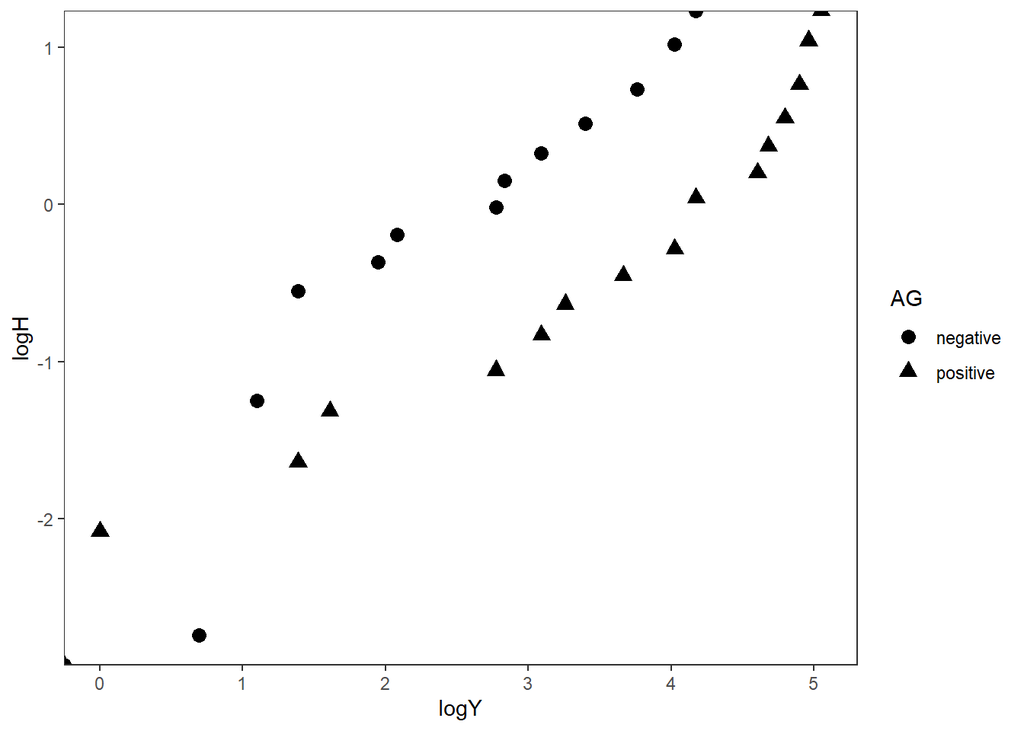

```r
survival_AG |> mutate(logH=log(-log(S)),
               logY=log(time)) |> ggplot(aes(x=logY, y=logH)) + geom_point(aes(shape = AG), size=3) +
  theme_bw() + theme(
  # Hide panel borders and remove grid lines
  #panel.border = element_line(colour = "black"),
  panel.grid.major = element_blank(),
  panel.grid.minor = element_blank(),
  # Change axis line
  #axis.line = element_line(colour = "black")
)
```

```r
#the exponential model can be fitted:
res.leukemia_survival.poisson<-glm(rep(1, length(AG))~AG + offset(log(Survival.time)), family=poisson(),
                  data=leukemia_survival)
summary(res.leukemia_survival.poisson)
```

```
##
## Call:
## glm(formula = rep(1, length(AG)) ~ AG + offset(log(Survival.time)),
##     family = poisson(), data = leukemia_survival)
##
## Coefficients:
##             Estimate Std. Error z value Pr(>|z|)
## (Intercept)  -2.8869     0.2500 -11.548  < 2e-16 ***
## AGpositive   -1.2478     0.3483  -3.582  0.00034 ***
## ---
## Signif. codes:  0 '***' 0.001 '**' 0.01 '*' 0.05 '.' 0.1 ' ' 1
##
## (Dispersion parameter for poisson family taken to be 1)
##
##     Null deviance: 58.138  on 32  degrees of freedom
## Residual deviance: 46.198  on 31  degrees of freedom
##   (1 observation deleted due to missingness)
## AIC: 116.2
##
## Number of Fisher Scoring iterations: 6
```

```r
#AIC
AIC(res.leukemia_survival.poisson)
```

```
## [1] 116.1983
```

```r
-2* logLik(res.leukemia_survival.poisson)+2*2
```

```
## 'log Lik.' 116.1983 (df=2)
```

```r
res.leukemia_survival.weibull <-survreg(Surv(Survival.time)~AG,dist="weibull", data=leukemia_survival)
summary(res.leukemia_survival.weibull)
```

```
##
## Call:
## survreg(formula = Surv(Survival.time) ~ AG, data = leukemia_survival,
##     dist = "weibull")
##             Value Std. Error    z      p
## (Intercept) 2.836      0.285 9.95 <2e-16
## AGpositive  1.258      0.385 3.27 0.0011
## Log(scale)  0.100      0.141 0.71 0.4767
##
## Scale= 1.11
##
## Weibull distribution
## Loglik(model)= -149.2   Loglik(intercept only)= -153.6
##  Chisq= 8.74 on 1 degrees of freedom, p= 0.0031
## Number of Newton-Raphson Iterations: 6
## n=33 (1 observation deleted due to missingness)
```

```r
mu <- res.leukemia_survival.poisson$fitted.values
y <- leukemia_survival$Survival.time[1:33]
m <- length(mu)
#lambda_hat
m/sum((mu-1)*log(y), na.rm = TRUE)
```

```
## [1] 0.8594624
```

```r
res.leukemia_survival.weibull2 <-survreg(Surv(Survival.time)~AG+log(White.blood.cell),dist="weibull", data=leukemia_survival)
summary(res.leukemia_survival.weibull2)
```

```
##
## Call:
## survreg(formula = Surv(Survival.time) ~ AG + log(White.blood.cell),
##     data = leukemia_survival, dist = "weibull")
##                         Value Std. Error     z       p
## (Intercept)            3.7087     0.4727  7.85 4.3e-15
## AGpositive             1.0206     0.3781  2.70  0.0069
## log(White.blood.cell) -0.3103     0.1313 -2.36  0.0181
## Log(scale)             0.0399     0.1392  0.29  0.7745
##
## Scale= 1.04
##
## Weibull distribution
## Loglik(model)= -146.5   Loglik(intercept only)= -153.6
##  Chisq= 14.18 on 2 degrees of freedom, p= 0.00084
## Number of Newton-Raphson Iterations: 6
## n=33 (1 observation deleted due to missingness)
```

```r
exp(-0.3103)
```

```
## [1] 0.733227
```

## Chapter11 Clustered and Longitudinal Data

```r
stroke.wide
```

```
## # A tibble: 24 × 10
##    Subject Group week1 week2 week3 week4 week5 week6 week7 week8
##      <dbl> <chr> <dbl> <dbl> <dbl> <dbl> <dbl> <dbl> <dbl> <dbl>
##  1       1 A        45    45    45    45    80    80    80    90
##  2       2 A        20    25    25    25    30    35    30    50
##  3       3 A        50    50    55    70    70    75    90    90
##  4       4 A        25    25    35    40    60    60    70    80
##  5       5 A       100   100   100   100   100   100   100   100
##  6       6 A        20    20    30    50    50    60    85    95
##  7       7 A        30    35    35    40    50    60    75    85
##  8       8 A        30    35    45    50    55    65    65    70
##  9       9 B        40    55    60    70    80    85    90    90
## 10      10 B        65    65    70    70    80    80    80    80
## 11      11 B        30    30    40    45    65    85    85    85
## 12      12 B        25    35    35    35    40    45    45    45
## 13      13 B        45    45    80    80    80    80    80    80
## 14      14 B        15    15    10    10    10    20    20    20
## 15      15 B        35    35    35    45    45    45    50    50
## 16      16 B        40    40    40    55    55    55    60    65
## 17      17 C        20    20    30    30    30    30    30    30
## 18      18 C        35    35    35    40    40    40    40    40
## 19      19 C        35    35    35    40    40    40    45    45
## 20      20 C        45    65    65    65    80    85    95   100
## 21      21 C        45    65    70    90    90    95    95   100
## 22      22 C        25    30    30    35    40    40    40    40
## 23      23 C        25    25    30    30    30    30    35    40
## 24      24 C        15    35    35    35    40    50    65    65
```

```r
library(tidyverse)
stroke.wide |> pivot_longer(
    cols = starts_with("week"),
    names_to = "week",
    values_to = "score",
    values_drop_na = TRUE
  ) |>
  mutate(
    week = readr::parse_number(week)
  )
```

```
## # A tibble: 192 × 4
##    Subject Group  week score
##      <dbl> <chr> <dbl> <dbl>
##  1       1 A         1    45
##  2       1 A         2    45
##  3       1 A         3    45
##  4       1 A         4    45
##  5       1 A         5    80
##  6       1 A         6    80
##  7       1 A         7    80
##  8       1 A         8    90
##  9       2 A         1    20
## 10       2 A         2    25
## 11       2 A         3    25
## 12       2 A         4    25
## 13       2 A         5    30
## 14       2 A         6    35
## 15       2 A         7    30
## 16       2 A         8    50
## 17       3 A         1    50
## 18       3 A         2    50
## 19       3 A         3    55
## 20       3 A         4    70
## 21       3 A         5    70
## 22       3 A         6    75
## 23       3 A         7    90
## 24       3 A         8    90
## 25       4 A         1    25
## # ℹ 167 more rows
```

```r
stroke.long <- stroke.wide |> pivot_longer(
    cols = starts_with("week"),
    names_to = "week",
    values_to = "score",
    values_drop_na = TRUE
  ) |>
  mutate(
    week = readr::parse_number(week)
  )
stroke.long
```

```
## # A tibble: 192 × 4
##    Subject Group  week score
##      <dbl> <chr> <dbl> <dbl>
##  1       1 A         1    45
##  2       1 A         2    45
##  3       1 A         3    45
##  4       1 A         4    45
##  5       1 A         5    80
##  6       1 A         6    80
##  7       1 A         7    80
##  8       1 A         8    90
##  9       2 A         1    20
## 10       2 A         2    25
## 11       2 A         3    25
## 12       2 A         4    25
## 13       2 A         5    30
## 14       2 A         6    35
## 15       2 A         7    30
## 16       2 A         8    50
## 17       3 A         1    50
## 18       3 A         2    50
## 19       3 A         3    55
## 20       3 A         4    70
## 21       3 A         5    70
## 22       3 A         6    75
## 23       3 A         7    90
## 24       3 A         8    90
## 25       4 A         1    25
## # ℹ 167 more rows
```

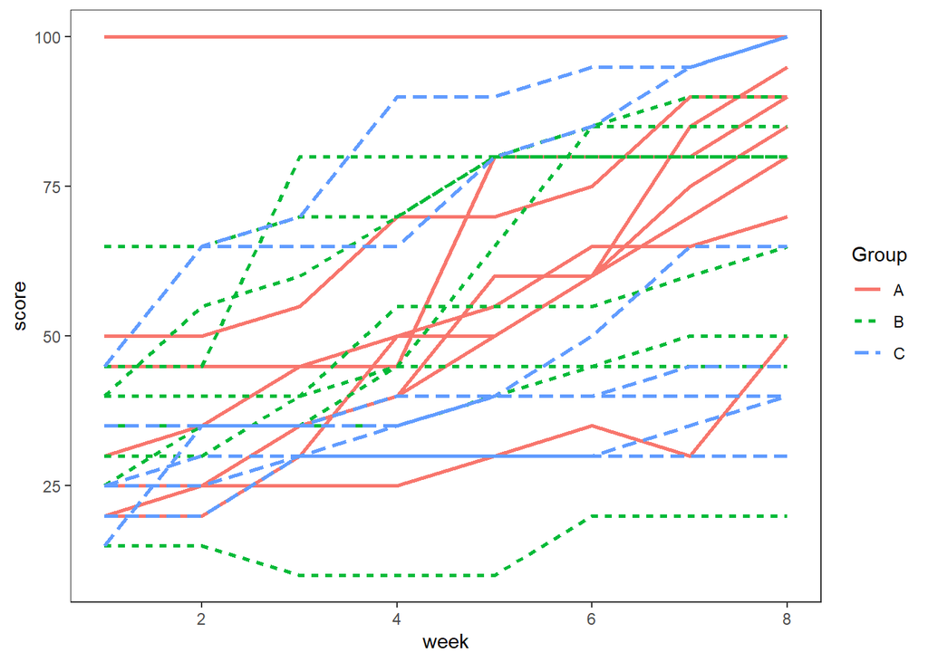

```r
stroke.long |> ggplot(aes(x=week, y=score, group=Subject)) +
  geom_line(aes(color = Group, linetype = Group), size=1) + theme_bw() + theme(
  # Hide panel borders and remove grid lines
  #panel.border = element_line(colour = "black"),
  panel.grid.major = element_blank(),
  panel.grid.minor = element_blank(),
  # Change axis line
  #axis.line = element_line(colour = "black")
)
```

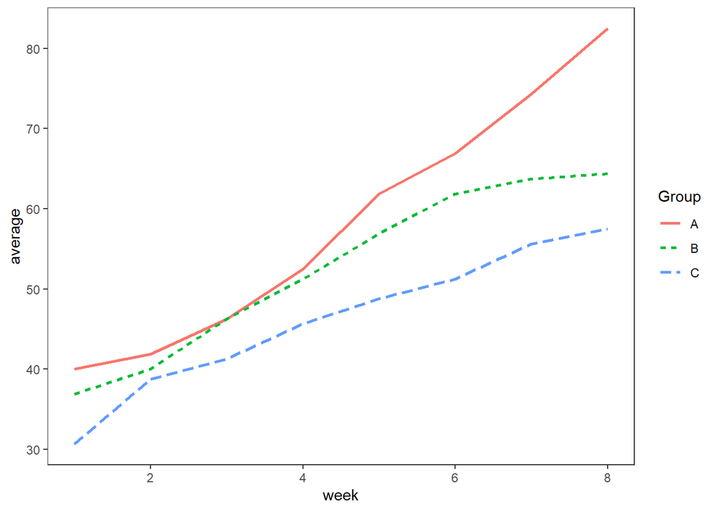

```r
stroke.long |>
  group_by(Group,week) |>
  summarize(average=mean(score, na.rm = TRUE),
            .groups = "drop") |>
  ggplot(aes(x=week, y=average)) +
  geom_line(aes(color = Group, linetype = Group), size=1) + theme_bw() + theme(
  # Hide panel borders and remove grid lines
  #panel.border = element_line(colour = "black"),
  panel.grid.major = element_blank(),
  panel.grid.minor = element_blank(),
  # Change axis line
  #axis.line = element_line(colour = "black")
)
```

```r
stroke.wide
```

```
## # A tibble: 24 × 10
##    Subject Group week1 week2 week3 week4 week5 week6 week7 week8
##      <dbl> <chr> <dbl> <dbl> <dbl> <dbl> <dbl> <dbl> <dbl> <dbl>
##  1       1 A        45    45    45    45    80    80    80    90
##  2       2 A        20    25    25    25    30    35    30    50
##  3       3 A        50    50    55    70    70    75    90    90
##  4       4 A        25    25    35    40    60    60    70    80
##  5       5 A       100   100   100   100   100   100   100   100
##  6       6 A        20    20    30    50    50    60    85    95
##  7       7 A        30    35    35    40    50    60    75    85
##  8       8 A        30    35    45    50    55    65    65    70
##  9       9 B        40    55    60    70    80    85    90    90
## 10      10 B        65    65    70    70    80    80    80    80
## 11      11 B        30    30    40    45    65    85    85    85
## 12      12 B        25    35    35    35    40    45    45    45
## 13      13 B        45    45    80    80    80    80    80    80
## 14      14 B        15    15    10    10    10    20    20    20
## 15      15 B        35    35    35    45    45    45    50    50
## 16      16 B        40    40    40    55    55    55    60    65
## 17      17 C        20    20    30    30    30    30    30    30
## 18      18 C        35    35    35    40    40    40    40    40
## 19      19 C        35    35    35    40    40    40    45    45
## 20      20 C        45    65    65    65    80    85    95   100
## 21      21 C        45    65    70    90    90    95    95   100
## 22      22 C        25    30    30    35    40    40    40    40
## 23      23 C        25    25    30    30    30    30    35    40
## 24      24 C        15    35    35    35    40    50    65    65
```

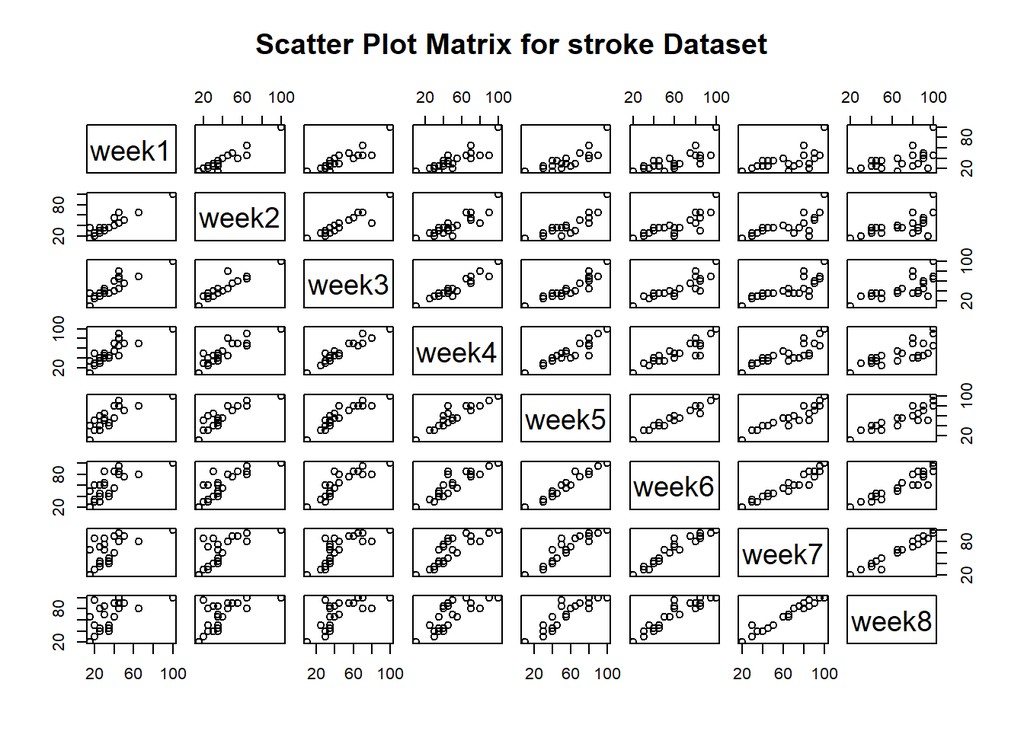

```r
pairs(stroke.wide[, 3:10], main = "Scatter Plot Matrix for stroke Dataset")
```

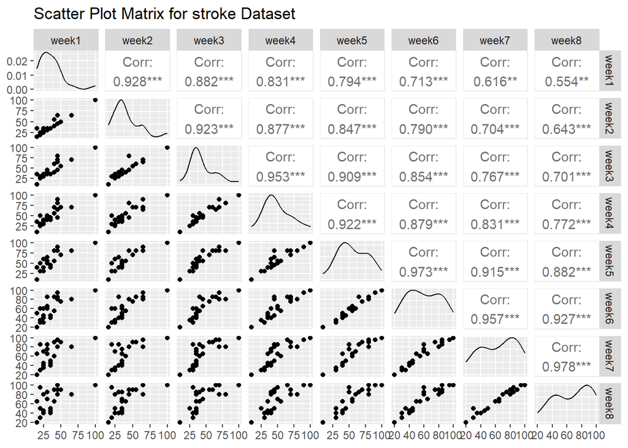

```r
library(ggplot2)
library(GGally)
ggpairs(stroke.wide[, 3:10],
        title = "Scatter Plot Matrix for stroke Dataset",
        axisLabels = "show")
```

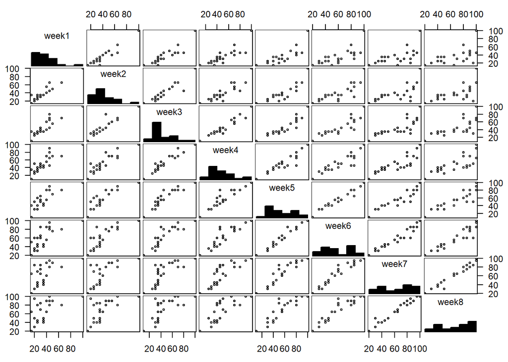

```r
library("gpairs")
gpairs(data.frame(stroke.wide[, 3:10]))
```

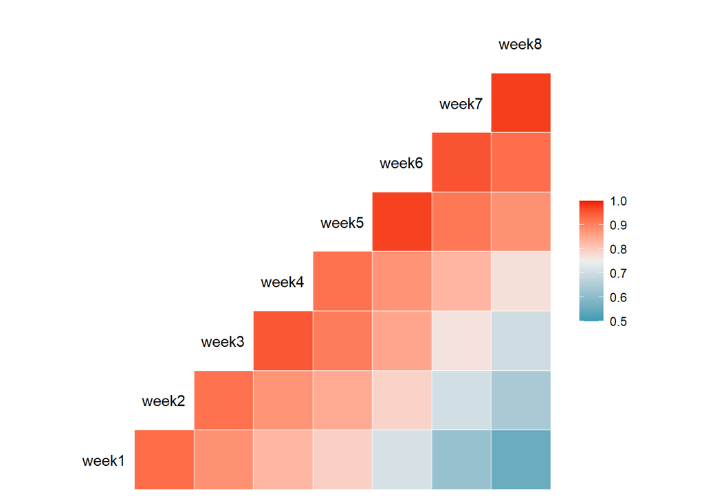

```r
library(ggplot2)
ggcorr(stroke.wide[, 3:10],
       low = "#3B9AB2",
       mid = "#EEEEEE",
       high = "#F21A00",
       midpoint = 0.75,
       limits = c(0.5, 1))
```

```r
cor(stroke.wide[, 3:10], method = c("pearson"))
```

```
##           week1     week2     week3     week4     week5     week6     week7
## week1 1.0000000 0.9280364 0.8820153 0.8306544 0.7936646 0.7125630 0.6163514
## week2 0.9280364 1.0000000 0.9225559 0.8774061 0.8466833 0.7895900 0.7041487
## week3 0.8820153 0.9225559 1.0000000 0.9530914 0.9092148 0.8542616 0.7667288
## week4 0.8306544 0.8774061 0.9530914 1.0000000 0.9215159 0.8786341 0.8313352
## week5 0.7936646 0.8466833 0.9092148 0.9215159 1.0000000 0.9734304 0.9149511
## week6 0.7125630 0.7895900 0.8542616 0.8786341 0.9734304 1.0000000 0.9569344
## week7 0.6163514 0.7041487 0.7667288 0.8313352 0.9149511 0.9569344 1.0000000
## week8 0.5544246 0.6425992 0.7007907 0.7716004 0.8819552 0.9266933 0.9776126
##           week8
## week1 0.5544246
## week2 0.6425992
## week3 0.7007907
## week4 0.7716004
## week5 0.8819552
## week6 0.9266933
## week7 0.9776126
## week8 1.0000000
```

```r
#model 11.1
#Table11.3
lmodel1 <- lm(score ~ Group+week, data = stroke.long)
summary(lmodel1)
```

```
##
## Call:
## lm(formula = score ~ Group + week, data = stroke.long)
##
## Residuals:
##     Min      1Q  Median      3Q     Max
## -49.332 -13.907  -4.532  15.043  58.394
##
## Coefficients:
##             Estimate Std. Error t value Pr(>|t|)
## (Intercept)  36.8415     3.9712   9.277  < 2e-16 ***
## GroupB       -5.6250     3.7147  -1.514  0.13164
## GroupC      -12.1094     3.7147  -3.260  0.00132 **
## week          4.7644     0.6619   7.198 1.42e-11 ***
## ---
## Signif. codes:  0 '***' 0.001 '**' 0.01 '*' 0.05 '.' 0.1 ' ' 1
##
## Residual standard error: 21.01 on 188 degrees of freedom
## Multiple R-squared:  0.2494, Adjusted R-squared:  0.2374
## F-statistic: 20.82 on 3 and 188 DF,  p-value: 1.084e-11
```

```r
#model 11.2
lmodel2 <- lm(score ~ Group*week, data = stroke.long)
summary(lmodel2)
```

```
##
## Call:
## lm(formula = score ~ Group * week, data = stroke.long)
##
## Residuals:
##     Min      1Q  Median      3Q     Max
## -47.813 -13.560  -5.305  13.337  63.854
##
## Coefficients:
##             Estimate Std. Error t value Pr(>|t|)
## (Intercept) 29.82143    5.77401   5.165 6.16e-07 ***
## GroupB       3.34821    8.16569   0.410   0.6823
## GroupC      -0.02232    8.16569  -0.003   0.9978
## week         6.32440    1.14342   5.531 1.07e-07 ***
## GroupB:week -1.99405    1.61705  -1.233   0.2191
## GroupC:week -2.68601    1.61705  -1.661   0.0984 .
## ---
## Signif. codes:  0 '***' 0.001 '**' 0.01 '*' 0.05 '.' 0.1 ' ' 1
##
## Residual standard error: 20.96 on 186 degrees of freedom
## Multiple R-squared:  0.2612, Adjusted R-squared:  0.2413
## F-statistic: 13.15 on 5 and 186 DF,  p-value: 5.695e-11
```

```r
#Estimates of intercepts and slopes (and their standard errors) for each subject
#model 11.3, table 11.4
library(dplyr)
library(broom)
stroke.long |> group_by(Subject) |>
  do(model = lm(score ~ week, data = .)) |>
  pull(model)
```

```
## [[1]]
##
## Call:
## lm(formula = score ~ week, data = .)
##
## Coefficients:
## (Intercept)         week
##        30.0          7.5
##
##
## [[2]]
##
## Call:
## lm(formula = score ~ week, data = .)
##
## Coefficients:
## (Intercept)         week
##      15.536        3.214
##
##
## [[3]]
##
## Call:
## lm(formula = score ~ week, data = .)
##
## Coefficients:
## (Intercept)         week
##      39.821        6.429
##
##
## [[4]]
##
## Call:
## lm(formula = score ~ week, data = .)
##
## Coefficients:
## (Intercept)         week
##      11.607        8.393
##
##
```

[output cut: 183 more lines]

```
## lm(formula = score ~ week, data = .)
##
## Coefficients:
## (Intercept)         week
##      22.321        1.845
##
##
## [[24]]
##
## Call:
## lm(formula = score ~ week, data = .)
##
## Coefficients:
## (Intercept)         week
##      13.036        6.548
```

```r
stroke.long |> group_by(Subject) |>
  do(model = lm(score ~ week, data = .)) |>
  pull(model) |> purrr::map(summary)
```

```
## [[1]]
##
## Call:
## lm(formula = score ~ week, data = .)
##
## Residuals:
##     Min      1Q  Median      3Q     Max
## -15.000  -3.750   0.000   5.625  12.500
##
## Coefficients:
##             Estimate Std. Error t value Pr(>|t|)
## (Intercept)   30.000      7.289   4.116  0.00624 **
## week           7.500      1.443   5.196  0.00202 **
## ---
## Signif. codes:  0 '***' 0.001 '**' 0.01 '*' 0.05 '.' 0.1 ' ' 1
##
## Residual standard error: 9.354 on 6 degrees of freedom
## Multiple R-squared:  0.8182, Adjusted R-squared:  0.7879
## F-statistic:    27 on 1 and 6 DF,  p-value: 0.002022
##
##
## [[2]]
##
## Call:
## lm(formula = score ~ week, data = .)
##
## Residuals:
##    Min     1Q Median     3Q    Max
## -8.036 -2.054  0.000  1.696  8.750
##
## Coefficients:
##             Estimate Std. Error t value Pr(>|t|)
## (Intercept)  15.5357     4.0994   3.790  0.00908 **
## week          3.2143     0.8118   3.959  0.00746 **
## ---
## Signif. codes:  0 '***' 0.001 '**' 0.01 '*' 0.05 '.' 0.1 ' ' 1
##
## Residual standard error: 5.261 on 6 degrees of freedom
## Multiple R-squared:  0.7232, Adjusted R-squared:  0.6771
## F-statistic: 15.68 on 1 and 6 DF,  p-value: 0.007456
```

[output cut: 447 more lines]

```
##
## Residuals:
##    Min     1Q Median     3Q    Max
## -5.774 -4.316 -1.369  3.274  8.869
##
## Coefficients:
##             Estimate Std. Error t value Pr(>|t|)
## (Intercept)  13.0357     4.4920   2.902 0.027263 *
## week          6.5476     0.8895   7.361 0.000322 ***
## ---
## Signif. codes:  0 '***' 0.001 '**' 0.01 '*' 0.05 '.' 0.1 ' ' 1
##
## Residual standard error: 5.765 on 6 degrees of freedom
## Multiple R-squared:  0.9003, Adjusted R-squared:  0.8837
## F-statistic: 54.18 on 1 and 6 DF,  p-value: 0.000322
```

```r
library(tidyverse)
models <- stroke.long |> group_by(Subject) |>
  do(model = lm(score ~ week, data = .)) |>
  pull(model) |> purrr::map(tidy)
models[[1]][,1:3]
```

```
## # A tibble: 2 × 3
##   term        estimate std.error
##   <chr>          <dbl>     <dbl>
## 1 (Intercept)     30        7.29
## 2 week             7.5      1.44
```

```r
models[[1]][,1:3] |> pivot_wider(names_from = term, values_from = c(estimate, std.error))
```

```
## # A tibble: 1 × 4
##   `estimate_(Intercept)` estimate_week `std.error_(Intercept)` std.error_week
##                    <dbl>         <dbl>                   <dbl>          <dbl>
## 1                     30           7.5                    7.29           1.44
```

```r
#Table11.4
models2 <- models |> purrr::map(\(table) table[,1:3]) |>
  map(~ (pivot_wider(.x, names_from=1,values_from= c(2,3))))
models2
```

```
## [[1]]
## # A tibble: 1 × 4
##   `estimate_(Intercept)` estimate_week `std.error_(Intercept)` std.error_week
##                    <dbl>         <dbl>                   <dbl>          <dbl>
## 1                     30           7.5                    7.29           1.44
##
## [[2]]
## # A tibble: 1 × 4
##   `estimate_(Intercept)` estimate_week `std.error_(Intercept)` std.error_week
##                    <dbl>         <dbl>                   <dbl>          <dbl>
## 1                   15.5          3.21                    4.10          0.812
##
## [[3]]
## # A tibble: 1 × 4
##   `estimate_(Intercept)` estimate_week `std.error_(Intercept)` std.error_week
##                    <dbl>         <dbl>                   <dbl>          <dbl>
## 1                   39.8          6.43                    3.21          0.636
##
## [[4]]
## # A tibble: 1 × 4
##   `estimate_(Intercept)` estimate_week `std.error_(Intercept)` std.error_week
##                    <dbl>         <dbl>                   <dbl>          <dbl>
## 1                   11.6          8.39                    3.39          0.671
##
## [[5]]
## # A tibble: 1 × 4
##   `estimate_(Intercept)` estimate_week `std.error_(Intercept)` std.error_week
##                    <dbl>         <dbl>                   <dbl>          <dbl>
## 1                    100             0                       0              0
##
## [[6]]
## # A tibble: 1 × 4
##   `estimate_(Intercept)` estimate_week `std.error_(Intercept)` std.error_week
##                    <dbl>         <dbl>                   <dbl>          <dbl>
## 1                  0.893          11.2                    5.30           1.05
##
## [[7]]
## # A tibble: 1 × 4
##   `estimate_(Intercept)` estimate_week `std.error_(Intercept)` std.error_week
##                    <dbl>         <dbl>                   <dbl>          <dbl>
```

[output cut: 88 more lines]

```
##   `estimate_(Intercept)` estimate_week `std.error_(Intercept)` std.error_week
##                    <dbl>         <dbl>                   <dbl>          <dbl>
## 1                   24.8          2.26                    1.89          0.373
##
## [[23]]
## # A tibble: 1 × 4
##   `estimate_(Intercept)` estimate_week `std.error_(Intercept)` std.error_week
##                    <dbl>         <dbl>                   <dbl>          <dbl>
## 1                   22.3          1.85                    1.71          0.338
##
## [[24]]
## # A tibble: 1 × 4
##   `estimate_(Intercept)` estimate_week `std.error_(Intercept)` std.error_week
##                    <dbl>         <dbl>                   <dbl>          <dbl>
## 1                   13.0          6.55                    4.49          0.890
```

```r
#Table 11.4
names(models2) <- seq(1:24)
bind_rows(models2, .id = "Subject")
```

```
## # A tibble: 24 × 5
##    Subject `estimate_(Intercept)` estimate_week `std.error_(Intercept)`
##    <chr>                    <dbl>         <dbl>                   <dbl>
##  1 1                       30             7.5                      7.29
##  2 2                       15.5           3.21                     4.10
##  3 3                       39.8           6.43                     3.21
##  4 4                       11.6           8.39                     3.39
##  5 5                      100             0                        0
##  6 6                        0.893        11.2                      5.30
##  7 7                       15.4           7.98                     4.67
##  8 8                       25.4           5.89                     1.97
##  9 9                       38.6           7.26                     3.52
## 10 10                      62.0           2.62                     2.24
## 11 11                      14.5           9.70                     5.89
## 12 12                      26.1           2.68                     2.15
## 13 13                      48.8           5                        8.93
## 14 14                      10.2           1.07                     3.21
## 15 15                      31.3           2.5                      1.95
## 16 16                      34.1           3.81                     2.81
## 17 17                      21.1           1.43                     2.55
## 18 18                      34.1           0.893                    1.16
## 19 19                      32.1           1.61                     1.16
## 20 20                      42.3           7.26                     3.70
## 21 21                      48.6           7.26                     6.14
## 22 22                      24.8           2.26                     1.89
## 23 23                      22.3           1.85                     1.71
## 24 24                      13.0           6.55                     4.49
## # ℹ 1 more variable: std.error_week <dbl>
```

```r
models3 <- bind_rows(models2, .id = "Subject")
models3["Groups"] <- factor(c(rep("A", 8), rep("B", 8), rep("C", 8)))
models3
```

```
## # A tibble: 24 × 6
##    Subject `estimate_(Intercept)` estimate_week `std.error_(Intercept)`
##    <chr>                    <dbl>         <dbl>                   <dbl>
##  1 1                       30             7.5                      7.29
##  2 2                       15.5           3.21                     4.10
##  3 3                       39.8           6.43                     3.21
##  4 4                       11.6           8.39                     3.39
##  5 5                      100             0                        0
##  6 6                        0.893        11.2                      5.30
##  7 7                       15.4           7.98                     4.67
##  8 8                       25.4           5.89                     1.97
##  9 9                       38.6           7.26                     3.52
## 10 10                      62.0           2.62                     2.24
## 11 11                      14.5           9.70                     5.89
## 12 12                      26.1           2.68                     2.15
## 13 13                      48.8           5                        8.93
## 14 14                      10.2           1.07                     3.21
## 15 15                      31.3           2.5                      1.95
## 16 16                      34.1           3.81                     2.81
## 17 17                      21.1           1.43                     2.55
## 18 18                      34.1           0.893                    1.16
## 19 19                      32.1           1.61                     1.16
## 20 20                      42.3           7.26                     3.70
## 21 21                      48.6           7.26                     6.14
## 22 22                      24.8           2.26                     1.89
## 23 23                      22.3           1.85                     1.71
## 24 24                      13.0           6.55                     4.49
## # ℹ 2 more variables: std.error_week <dbl>, Groups <fct>
```

```r
#Table 11.5 Analysis of variance of intercept estimates
summary(lm(`estimate_(Intercept)` ~ Groups, data = models3))
```

```
##
## Call:
## lm(formula = `estimate_(Intercept)` ~ Groups, data = models3)
##
## Residuals:
##     Min      1Q  Median      3Q     Max
## -28.929 -14.330  -3.192   6.551  70.179
##
## Coefficients:
##             Estimate Std. Error t value Pr(>|t|)
## (Intercept) 29.82143    7.57209   3.938 0.000753 ***
## GroupsB      3.34821   10.70855   0.313 0.757617
## GroupsC     -0.02232   10.70855  -0.002 0.998357
## ---
## Signif. codes:  0 '***' 0.001 '**' 0.01 '*' 0.05 '.' 0.1 ' ' 1
##
## Residual standard error: 21.42 on 21 degrees of freedom
## Multiple R-squared:  0.00621,    Adjusted R-squared:  -0.08844
## F-statistic: 0.06561 on 2 and 21 DF,  p-value: 0.9367
```

```r
#Table 11.6 Analysis of variance of slope estimates
summary(lm(estimate_week ~ Groups, data = models3))
```

```
##
## Call:
## lm(formula = estimate_week ~ Groups, data = models3)
##
## Residuals:
##     Min      1Q  Median      3Q     Max
## -6.3244 -1.8806 -0.4762  2.2786  5.3720
##
## Coefficients:
##             Estimate Std. Error t value Pr(>|t|)
## (Intercept)    6.324      1.080   5.854 8.25e-06 ***
## GroupsB       -1.994      1.528  -1.305   0.2060
## GroupsC       -2.686      1.528  -1.758   0.0933 .
## ---
## Signif. codes:  0 '***' 0.001 '**' 0.01 '*' 0.05 '.' 0.1 ' ' 1
##
## Residual standard error: 3.056 on 21 degrees of freedom
## Multiple R-squared:  0.1369, Adjusted R-squared:  0.05475
## F-statistic: 1.666 on 2 and 21 DF,  p-value: 0.213
```

```r
stroke.long <- stroke.wide |> pivot_longer(
    cols = starts_with("week"),
    names_to = "week",
    values_to = "score",
    values_drop_na = TRUE
  ) |>
  mutate(
    week = readr::parse_number(week),
    Group = factor(Group)
  )
colnames(stroke.long) <- c("Subject","Group","time","ability")
stroke.long
```

```
## # A tibble: 192 × 4
##    Subject Group  time ability
##      <dbl> <fct> <dbl>   <dbl>
##  1       1 A         1      45
##  2       1 A         2      45
##  3       1 A         3      45
##  4       1 A         4      45
##  5       1 A         5      80
##  6       1 A         6      80
##  7       1 A         7      80
##  8       1 A         8      90
##  9       2 A         1      20
## 10       2 A         2      25
## 11       2 A         3      25
## 12       2 A         4      25
## 13       2 A         5      30
## 14       2 A         6      35
## 15       2 A         7      30
## 16       2 A         8      50
## 17       3 A         1      50
## 18       3 A         2      50
## 19       3 A         3      55
## 20       3 A         4      70
## 21       3 A         5      70
## 22       3 A         6      75
## 23       3 A         7      90
## 24       3 A         8      90
## 25       4 A         1      25
## # ℹ 167 more rows
```

```r
#model 11.2 pooled
lmodel2 <- glm(ability ~ Group*time, data = stroke.long)
summary(lmodel2)
```

```
##
## Call:
## glm(formula = ability ~ Group * time, data = stroke.long)
##
## Coefficients:
##             Estimate Std. Error t value Pr(>|t|)
## (Intercept) 29.82143    5.77401   5.165 6.16e-07 ***
## GroupB       3.34821    8.16569   0.410   0.6823
## GroupC      -0.02232    8.16569  -0.003   0.9978
## time         6.32440    1.14342   5.531 1.07e-07 ***
## GroupB:time -1.99405    1.61705  -1.233   0.2191
## GroupC:time -2.68601    1.61705  -1.661   0.0984 .
## ---
## Signif. codes:  0 '***' 0.001 '**' 0.01 '*' 0.05 '.' 0.1 ' ' 1
##
## (Dispersion parameter for gaussian family taken to be 439.2931)
##
##     Null deviance: 110597  on 191  degrees of freedom
## Residual deviance:  81709  on 186  degrees of freedom
## AIC: 1721.1
##
## Number of Fisher Scoring iterations: 2
```

The estimate of $\sigma_e$ is square root of the deviance divided by the degrees of freedom

```r
lmodel2$df.residual
```

```
## [1] 186
```

```r
lmodel2$deviance
```

```
## [1] 81708.52
```

```r
#The estimate of \sigma_e is
sqrt(lmodel2$deviance/lmodel2$df.residual)
```

```
## [1] 20.95932
```

```r
#the deviance
sum((lmodel2$fitted.values - lmodel2$data$ability)^2)
```

```
## [1] 81708.52
```

```r
#Data reduction
summary(lm(`estimate_(Intercept)` ~ Groups, data = models3))
```

```
##
## Call:
## lm(formula = `estimate_(Intercept)` ~ Groups, data = models3)
##
## Residuals:
##     Min      1Q  Median      3Q     Max
## -28.929 -14.330  -3.192   6.551  70.179
##
## Coefficients:
##             Estimate Std. Error t value Pr(>|t|)
## (Intercept) 29.82143    7.57209   3.938 0.000753 ***
## GroupsB      3.34821   10.70855   0.313 0.757617
## GroupsC     -0.02232   10.70855  -0.002 0.998357
## ---
## Signif. codes:  0 '***' 0.001 '**' 0.01 '*' 0.05 '.' 0.1 ' ' 1
##
## Residual standard error: 21.42 on 21 degrees of freedom
## Multiple R-squared:  0.00621,    Adjusted R-squared:  -0.08844
## F-statistic: 0.06561 on 2 and 21 DF,  p-value: 0.9367
```

```r
summary(lm(estimate_week ~ Groups, data = models3))
```

```
##
## Call:
## lm(formula = estimate_week ~ Groups, data = models3)
##
## Residuals:
##     Min      1Q  Median      3Q     Max
## -6.3244 -1.8806 -0.4762  2.2786  5.3720
##
## Coefficients:
##             Estimate Std. Error t value Pr(>|t|)
## (Intercept)    6.324      1.080   5.854 8.25e-06 ***
## GroupsB       -1.994      1.528  -1.305   0.2060
## GroupsC       -2.686      1.528  -1.758   0.0933 .
## ---
## Signif. codes:  0 '***' 0.001 '**' 0.01 '*' 0.05 '.' 0.1 ' ' 1
##
## Residual standard error: 3.056 on 21 degrees of freedom
## Multiple R-squared:  0.1369, Adjusted R-squared:  0.05475
## F-statistic: 1.666 on 2 and 21 DF,  p-value: 0.213
```

```r
library(geepack)
#GEE independent
gee.ind<-geeglm(ability~Group*time,
                family=gaussian("identity"),
                data=stroke.long,
                id=Subject,
                wave=time,
                std.err = 'san.se',
                corst="independence")
summary(gee.ind)
```

```
##
## Call:
## geeglm(formula = ability ~ Group * time, family = gaussian("identity"),
##     data = stroke.long, id = Subject, waves = time, corstr = "independence",
##     std.err = "san.se")
##
##  Coefficients:
##             Estimate  Std.err   Wald Pr(>|W|)
## (Intercept) 29.82143 10.17573  8.589  0.00338 **
## GroupB       3.34821 11.63333  0.083  0.77349
## GroupC      -0.02232 10.89585  0.000  0.99837
## time         6.32440  1.13148 31.243 2.28e-08 ***
## GroupB:time -1.99405  1.47762  1.821  0.17718
## GroupC:time -2.68601  1.47010  3.338  0.06769 .
## ---
## Signif. codes:  0 '***' 0.001 '**' 0.01 '*' 0.05 '.' 0.1 ' ' 1
##
## Correlation structure = independence
## Estimated Scale Parameters:
##
##             Estimate Std.err
## (Intercept)    425.6   103.2
## Number of clusters:   24  Maximum cluster size: 8
```

```r
gee.ind$coefficients
```

```
## (Intercept)      GroupB      GroupC        time GroupB:time GroupC:time
##    29.82143     3.34821    -0.02232     6.32440    -1.99405    -2.68601
```

```r
summary(gee.ind)$coefficients
```

```
##             Estimate Std.err      Wald  Pr(>|W|)
## (Intercept) 29.82143  10.176 8.589e+00 3.383e-03
## GroupB       3.34821  11.633 8.284e-02 7.735e-01
## GroupC      -0.02232  10.896 4.197e-06 9.984e-01
## time         6.32440   1.131 3.124e+01 2.277e-08
## GroupB:time -1.99405   1.478 1.821e+00 1.772e-01
## GroupC:time -2.68601   1.470 3.338e+00 6.769e-02
```

```r
#GEE exchangeable
gee.exch<-geeglm(ability~Group*time,family=gaussian,
                 std.err = 'san.se',
                 data=stroke.long,
                 id=Subject,
                 wave=time,
                 corst="exchangeable")
summary(gee.exch)
```

```
##
## Call:
## geeglm(formula = ability ~ Group * time, family = gaussian, data = stroke.long,
##     id = Subject, waves = time, corstr = "exchangeable", std.err = "san.se")
##
##  Coefficients:
##             Estimate Std.err  Wald Pr(>|W|)
## (Intercept)  29.8214 10.1757  8.59   0.0034 **
## GroupB        3.3482 11.6333  0.08   0.7735
## GroupC       -0.0223 10.8958  0.00   0.9984
## time          6.3244  1.1315 31.24  2.3e-08 ***
## GroupB:time  -1.9940  1.4776  1.82   0.1772
## GroupC:time  -2.6860  1.4701  3.34   0.0677 .
## ---
## Signif. codes:  0 '***' 0.001 '**' 0.01 '*' 0.05 '.' 0.1 ' ' 1
##
## Correlation structure = exchangeable
## Estimated Scale Parameters:
##
##             Estimate Std.err
## (Intercept)      426     103
##   Link = identity
##
## Estimated Correlation Parameters:
##       Estimate Std.err
## alpha    0.831   0.035
## Number of clusters:   24  Maximum cluster size: 8
```

```r
gee.exch$cor.link
```

```
## [1] "identity"
```

```r
#the df
gee.exch$df.residual
```

```
## [1] 186
```

```r
#the deviance
sum((gee.exch$fitted.values - gee.exch$data$ability)^2)
```

```
## [1] 81709
```

```r
#The estimate of \sigma_e is
sqrt(sum((gee.exch$fitted.values - gee.exch$data$ability)^2)/gee.exch$df.residual)
```

```
## [1] 21
```

```r
#an autoregressive model of order 1, AR(1),
gee.ar1<-geeglm(ability~Group*time,
                family=gaussian,
                std.err = 'san.se',
                data=stroke.long,
                id=Subject,
                wave=time,
                corst="ar1")
summary(gee.ar1)
```

```
##
## Call:
## geeglm(formula = ability ~ Group * time, family = gaussian, data = stroke.long,
##     id = Subject, waves = time, corstr = "ar1", std.err = "san.se")
##
##  Coefficients:
##             Estimate Std.err  Wald Pr(>|W|)
## (Intercept)   33.239   9.757 11.61  0.00066 ***
## GroupB         0.121  10.957  0.00  0.99122
## GroupC        -5.960  10.376  0.33  0.56566
## time           6.077   1.035 34.45  4.4e-09 ***
## GroupB:time   -2.139   1.333  2.58  0.10854
## GroupC:time   -2.243   1.472  2.32  0.12756
## ---
## Signif. codes:  0 '***' 0.001 '**' 0.01 '*' 0.05 '.' 0.1 ' ' 1
##
## Correlation structure = ar1
## Estimated Scale Parameters:
##
##             Estimate Std.err
## (Intercept)      430     103
##   Link = identity
##
## Estimated Correlation Parameters:
##       Estimate Std.err
## alpha    0.933  0.0158
## Number of clusters:   24  Maximum cluster size: 8
```

```r
#the df
gee.ar1$df.residual
```

```
## [1] 186
```

```r
#the deviance
sum((gee.ar1$fitted.values - gee.ar1$data$ability)^2)
```

```
## [1] 82465
```

```r
#The estimate of \sigma_e is
sqrt(sum((gee.ar1$fitted.values - gee.ar1$data$ability)^2)/gee.ar1$df.residual)
```

```
## [1] 21.1
```

```r
summary(gee.ar1)$coefficients
```

```
##             Estimate Std.err     Wald Pr(>|W|)
## (Intercept)   33.239    9.76 1.16e+01 6.58e-04
## GroupB         0.121   10.96 1.21e-04 9.91e-01
## GroupC        -5.960   10.38 3.30e-01 5.66e-01
## time           6.077    1.04 3.44e+01 4.38e-09
## GroupB:time   -2.139    1.33 2.58e+00 1.09e-01
## GroupC:time   -2.243    1.47 2.32e+00 1.28e-01
```

```r
#GEE unstructured
gee.un<-geeglm(ability~Group*time,
               family=gaussian,
               data=stroke.long,
               id=Subject,
               wave=time,
               corst="unstructured")
summary(gee.un)
```

```
##
## Call:
## geeglm(formula = ability ~ Group * time, family = gaussian, data = stroke.long,
##     id = Subject, waves = time, corstr = "unstructured")
##
##  Coefficients:
##             Estimate  Std.err Wald Pr(>|W|)
## (Intercept)   27.536 1727.066    0     0.99
## GroupB         0.918 2222.037    0     1.00
## GroupC         1.549 2010.530    0     1.00
## time           6.879  469.581    0     0.99
## GroupB:time   -1.423  603.770    0     1.00
## GroupC:time   -3.073  546.696    0     1.00
##
## Correlation structure = unstructured
## Estimated Scale Parameters:
##
##             Estimate Std.err
## (Intercept)      428    2667
##   Link = identity
##
## Estimated Correlation Parameters:
##           Estimate Std.err
## alpha.1:2    0.713   15.87
## alpha.1:3    0.708   12.86
## alpha.1:4    0.694   10.97
## alpha.1:5    0.692   15.82
## alpha.1:6    0.601   10.88
## alpha.1:7    0.534    7.01
## alpha.1:8    0.462   24.01
## alpha.2:3    0.793    8.98
## alpha.2:4    0.796    9.58
## alpha.2:5    0.805    9.89
## alpha.2:6    0.746    7.69
## alpha.2:7    0.702    5.42
## alpha.2:8    0.638   22.63
## alpha.3:4    0.920   13.66
## alpha.3:5    0.914   10.99
## alpha.3:6    0.854   12.63
## alpha.3:7    0.810    7.49
## alpha.3:8    0.737   20.52
## alpha.4:5    0.972   11.63
## alpha.4:6    0.922   14.14
## alpha.4:7    0.922    9.75
## alpha.4:8    0.850   20.73
## alpha.5:6    1.046   10.89
## alpha.5:7    1.032    2.52
## alpha.5:8    0.979   19.20
## alpha.6:7    1.072    8.55
## alpha.6:8    1.023   20.63
## alpha.7:8    1.145   30.29
## Number of clusters:   24  Maximum cluster size: 8
```

```r
#the df
gee.un$df.residual
```

```
## [1] 186
```

```r
#the deviance
sum((gee.un$fitted.values - gee.un$data$ability)^2)
```

```
## [1] 82257
```

```r
#The estimate of \sigma_e is
sqrt(sum((gee.un$fitted.values - gee.un$data$ability)^2)/gee.un$df.residual)
```

```
## [1] 21
```

- `nlme::lme`: this package uses a “within-between” or parameter-counting approach, which is adequate for simpler model structures (single-term or nested models), but which gets progressively less applicable/harder for random-slopes models (see comments in the GLMM FAQ), crossed random effects, unbalanced designs, or more complex random effect structures where the random effects themselves are no longer iid

```r
#random effects models
library(nlme)
rndeff<-lme(ability~Group*time,
            data=stroke.long,
            random=~1|Subject)
summary(rndeff)
```

```
## Linear mixed-effects model fit by REML
##   Data: stroke.long
##    AIC  BIC logLik
##   1453 1479   -718
##
## Random effects:
##  Formula: ~1 | Subject
##         (Intercept) Residual
## StdDev:        20.1     8.56
##
## Fixed effects:  ability ~ Group * time
##             Value Std.Error  DF t-value p-value
## (Intercept) 29.82      7.50 165    3.98  0.0001
## GroupB       3.35     10.60  21    0.32  0.7553
## GroupC      -0.02     10.60  21    0.00  0.9983
## time         6.32      0.47 165   13.54  0.0000
## GroupB:time -1.99      0.66 165   -3.02  0.0030
## GroupC:time -2.69      0.66 165   -4.07  0.0001
##  Correlation:
##             (Intr) GroupB GroupC time   GrpB:t
## GroupB      -0.707
## GroupC      -0.707  0.500
## time        -0.280  0.198  0.198
## GroupB:time  0.198 -0.280 -0.140 -0.707
## GroupC:time  0.198 -0.140 -0.280 -0.707  0.500
##
## Standardized Within-Group Residuals:
##      Min       Q1      Med       Q3      Max
## -2.65509 -0.53335 -0.00376  0.53502  2.69237
##
## Number of Observations: 192
## Number of Groups: 24
```

```r
ind<-corAR1(form = ~ 1 | Subject)
gls.ind<-gls(ability~Group*time,
             data=stroke.long,
             correlation=ind)
summary(gls.ind)
```

```
## Generalized least squares fit by REML
##   Model: ability ~ Group * time
##   Data: stroke.long
##    AIC  BIC logLik
##   1320 1346   -652
##
## Correlation Structure: AR(1)
##  Formula: ~1 | Subject
##  Parameter estimate(s):
##  Phi
## 0.95
##
## Coefficients:
##             Value Std.Error t-value p-value
## (Intercept)  33.4      7.94    4.21  0.0000
## GroupB       -0.1     11.22   -0.01  0.9918
## GroupC       -6.2     11.22   -0.55  0.5798
## time          6.1      0.84    7.20  0.0000
## GroupB:time  -2.1      1.19   -1.79  0.0744
## GroupC:time  -2.2      1.19   -1.88  0.0622
##
##  Correlation:
##             (Intr) GroupB GroupC time   GrpB:t
## GroupB      -0.707
## GroupC      -0.707  0.500
## time        -0.478  0.338  0.338
## GroupB:time  0.338 -0.478 -0.239 -0.707
## GroupC:time  0.338 -0.239 -0.478 -0.707  0.500
##
## Standardized residuals:
##    Min     Q1    Med     Q3    Max
## -2.143 -0.586 -0.226  0.653  2.825
##
## Residual standard error: 21.4
## Degrees of freedom: 192 total; 186 residual
```

```r
gls.ind$coefficients
```

```
## (Intercept)      GroupB      GroupC        time GroupB:time GroupC:time
##      33.393      -0.115      -6.226       6.075      -2.141      -2.238
```

```r
summary(gls.ind)$coefficients
```

```
## (Intercept)      GroupB      GroupC        time GroupB:time GroupC:time
##      33.393      -0.115      -6.226       6.075      -2.141      -2.238
```

```r
exch<-corCompSymm(form = ~ 1 | Subject)
gls.exch<-gls(ability~Group*time,
              data=stroke.long,
              correlation=exch)
summary(gls.exch)
```

```
## Generalized least squares fit by REML
##   Model: ability ~ Group * time
##   Data: stroke.long
##    AIC  BIC logLik
##   1453 1479   -718
##
## Correlation Structure: Compound symmetry
##  Formula: ~1 | Subject
##  Parameter estimate(s):
##   Rho
## 0.847
##
## Coefficients:
##             Value Std.Error t-value p-value
## (Intercept) 29.82      7.50    3.98  0.0001
## GroupB       3.35     10.60    0.32  0.7525
## GroupC      -0.02     10.60    0.00  0.9983
## time         6.32      0.47   13.54  0.0000
## GroupB:time -1.99      0.66   -3.02  0.0029
## GroupC:time -2.69      0.66   -4.07  0.0001
##
##  Correlation:
##             (Intr) GroupB GroupC time   GrpB:t
## GroupB      -0.707
## GroupC      -0.707  0.500
## time        -0.280  0.198  0.198
## GroupB:time  0.198 -0.280 -0.140 -0.707
## GroupC:time  0.198 -0.140 -0.280 -0.707  0.500
##
## Standardized residuals:
##    Min     Q1    Med     Q3    Max
## -2.186 -0.620 -0.243  0.610  2.919
##
## Residual standard error: 21.9
## Degrees of freedom: 192 total; 186 residual
```

```r
summary(gls.exch)$coefficients
```

```
## (Intercept)      GroupB      GroupC        time GroupB:time GroupC:time
##     29.8214      3.3482     -0.0223      6.3244     -1.9940     -2.6860
```

```r
ar1<-corAR1(form = ~ 1 | Subject)
gls.ar1<-gls(ability~Group*time, data=stroke.long,
             correlation=ar1)
summary(gls.ar1)
```

```
## Generalized least squares fit by REML
##   Model: ability ~ Group * time
##   Data: stroke.long
##    AIC  BIC logLik
##   1320 1346   -652
##
## Correlation Structure: AR(1)
##  Formula: ~1 | Subject
##  Parameter estimate(s):
##  Phi
## 0.95
##
## Coefficients:
##             Value Std.Error t-value p-value
## (Intercept)  33.4      7.94    4.21  0.0000
## GroupB       -0.1     11.22   -0.01  0.9918
## GroupC       -6.2     11.22   -0.55  0.5798
## time          6.1      0.84    7.20  0.0000
## GroupB:time  -2.1      1.19   -1.79  0.0744
## GroupC:time  -2.2      1.19   -1.88  0.0622
##
##  Correlation:
##             (Intr) GroupB GroupC time   GrpB:t
## GroupB      -0.707
## GroupC      -0.707  0.500
## time        -0.478  0.338  0.338
## GroupB:time  0.338 -0.478 -0.239 -0.707
## GroupC:time  0.338 -0.239 -0.478 -0.707  0.500
##
## Standardized residuals:
##    Min     Q1    Med     Q3    Max
## -2.143 -0.586 -0.226  0.653  2.825
##
## Residual standard error: 21.4
## Degrees of freedom: 192 total; 186 residual
```

```r
un<-corSymm(form = ~ 1 | Subject)
gls.un<-gls(ability~Group+time+Group*time, data=stroke.long,
            correlation=un)
summary(gls.un)
```

```
## Generalized least squares fit by REML
##   Model: ability ~ Group + time + Group * time
##   Data: stroke.long
##    AIC  BIC logLik
##   1338 1451   -634
##
## Correlation Structure: General
##  Formula: ~1 | Subject
##  Parameter estimate(s):
##  Correlation:
##   1     2     3     4     5     6     7
## 2 0.931
## 3 0.868 0.931
## 4 0.789 0.875 0.952
## 5 0.708 0.819 0.892 0.913
## 6 0.576 0.731 0.815 0.855 0.965
## 7 0.426 0.606 0.693 0.782 0.886 0.945
## 8 0.319 0.522 0.609 0.707 0.840 0.908 0.975
##
## Coefficients:
##             Value Std.Error t-value p-value
## (Intercept)  35.7      7.94    4.50  0.0000
## GroupB       -5.5     11.24   -0.49  0.6244
## GroupC      -11.3     11.24   -1.01  0.3156
## time          6.7      1.17    5.74  0.0000
## GroupB:time  -3.2      1.65   -1.96  0.0512
## GroupC:time  -3.9      1.65   -2.34  0.0204
##
##  Correlation:
##             (Intr) GroupB GroupC time   GrpB:t
## GroupB      -0.707
## GroupC      -0.707  0.500
## time        -0.760  0.537  0.537
## GroupB:time  0.537 -0.760 -0.380 -0.707
## GroupC:time  0.537 -0.380 -0.760 -0.707  0.500
##
## Standardized residuals:
##     Min      Q1     Med      Q3     Max
## -2.4710 -0.5084 -0.0354  0.8261  2.7072
##
## Residual standard error: 21.3
## Degrees of freedom: 192 total; 186 residual
```

```r
AIC(gls.ind,gls.exch,gls.ar1,gls.un)
```

```
##          df  AIC
## gls.ind   8 1320
## gls.exch  8 1453
## gls.ar1   8 1320
## gls.un   35 1338
```

```r
#Exercises 11.1
#Table11.9
dogs
```

```
## # A tibble: 40 × 4
##      dog condition     y     x
##    <dbl>     <dbl> <dbl> <dbl>
##  1     1         1  81.7  54.3
##  2     1         2  84.3  62
##  3     1         3  72.8  62.3
##  4     1         4  71.7  47.3
##  5     1         5  76.7  53.6
##  6     1         6  75.8  38
##  7     1         7  77.3  54.2
##  8     1         8  86.3  54
##  9     2         1 105    81.5
## 10     2         2 114.   80.8
## 11     2         3 109.   74.5
## 12     2         4  83.9  71.9
## 13     2         5  89    79.5
## 14     2         6  86.1  73
## 15     2         7  88.7  74.7
## 16     2         8 118.   88.6
## 17     3         1  95.5  65
## 18     3         2  95.7  68.3
## 19     3         3  84    67.9
## 20     3         4  85.8  61
## 21     3         5  98.8  66
## 22     3         6 106.   81.8
## 23     3         7 106.   71.4
## 24     3         8 115    96
## 25     4         1 113.   87.5
## # ℹ 15 more rows
```

```r
#Pooled
Pooled.dogs <- glm(y ~ x, data = dogs)
summary(Pooled.dogs)
```

```
##
## Call:
## glm(formula = y ~ x, data = dogs)
##
## Coefficients:
##             Estimate Std. Error t value Pr(>|t|)
## (Intercept)  40.7681     6.6173    6.16  3.4e-07 ***
## x             0.7692     0.0916    8.40  3.4e-10 ***
## ---
## Signif. codes:  0 '***' 0.001 '**' 0.01 '*' 0.05 '.' 0.1 ' ' 1
##
## (Dispersion parameter for gaussian family taken to be 62.6)
##
##     Null deviance: 6795  on 39  degrees of freedom
## Residual deviance: 2378  on 38  degrees of freedom
## AIC: 282.9
##
## Number of Fisher Scoring iterations: 2
```

```r
models.dog <- dogs |> group_by(dog) |>
  do(model = lm(y ~ x, data = .)) |>
  pull(model) |> purrr::map(tidy)
models.dog
```

```
## [[1]]
## # A tibble: 2 × 5
##   term        estimate std.error statistic p.value
##   <chr>          <dbl>     <dbl>     <dbl>   <dbl>
## 1 (Intercept)   67.4      14.1       4.78  0.00305
## 2 x              0.206     0.262     0.784 0.463
##
## [[2]]
## # A tibble: 2 × 5
##   term        estimate std.error statistic p.value
##   <chr>          <dbl>     <dbl>     <dbl>   <dbl>
## 1 (Intercept)   -43.1     51.0      -0.845  0.430
## 2 x               1.82     0.651     2.80   0.0313
##
## [[3]]
## # A tibble: 2 × 5
##   term        estimate std.error statistic p.value
##   <chr>          <dbl>     <dbl>     <dbl>   <dbl>
## 1 (Intercept)   43.2      15.6        2.76  0.0327
## 2 x              0.765     0.214      3.57  0.0117
##
## [[4]]
## # A tibble: 2 × 5
##   term        estimate std.error statistic p.value
##   <chr>          <dbl>     <dbl>     <dbl>   <dbl>
## 1 (Intercept)   60.5      17.2        3.52  0.0126
## 2 x              0.547     0.212      2.58  0.0420
##
## [[5]]
## # A tibble: 2 × 5
##   term        estimate std.error statistic p.value
##   <chr>          <dbl>     <dbl>     <dbl>   <dbl>
## 1 (Intercept)   58.9      17.6        3.34  0.0155
## 2 x              0.530     0.244      2.17  0.0729
```

```r
models.dog2 <- models.dog |> purrr::map(\(table) table[,1:3]) |>
  map(~ (pivot_wider(.x, names_from=1,values_from= c(2,3))))
models.dog2
```

```
## [[1]]
## # A tibble: 1 × 4
##   `estimate_(Intercept)` estimate_x `std.error_(Intercept)` std.error_x
##                    <dbl>      <dbl>                   <dbl>       <dbl>
## 1                   67.4      0.206                    14.1       0.262
##
## [[2]]
## # A tibble: 1 × 4
##   `estimate_(Intercept)` estimate_x `std.error_(Intercept)` std.error_x
##                    <dbl>      <dbl>                   <dbl>       <dbl>
## 1                  -43.1       1.82                    51.0       0.651
##
## [[3]]
## # A tibble: 1 × 4
##   `estimate_(Intercept)` estimate_x `std.error_(Intercept)` std.error_x
##                    <dbl>      <dbl>                   <dbl>       <dbl>
## 1                   43.2      0.765                    15.6       0.214
##
## [[4]]
## # A tibble: 1 × 4
##   `estimate_(Intercept)` estimate_x `std.error_(Intercept)` std.error_x
##                    <dbl>      <dbl>                   <dbl>       <dbl>
## 1                   60.5      0.547                    17.2       0.212
##
## [[5]]
## # A tibble: 1 × 4
##   `estimate_(Intercept)` estimate_x `std.error_(Intercept)` std.error_x
##                    <dbl>      <dbl>                   <dbl>       <dbl>
## 1                   58.9      0.530                    17.6       0.244
```

```r
names(models.dog2) <- seq(1:5)
models.dog3 <- bind_rows(models.dog2, .id = "dog")
models.dog3["dog"] <- c(seq(1:5))
models.dog3
```

```
## # A tibble: 5 × 5
##     dog `estimate_(Intercept)` estimate_x `std.error_(Intercept)` std.error_x
##   <int>                  <dbl>      <dbl>                   <dbl>       <dbl>
## 1     1                   67.4      0.206                    14.1       0.262
## 2     2                  -43.1      1.82                     51.0       0.651
## 3     3                   43.2      0.765                    15.6       0.214
## 4     4                   60.5      0.547                    17.2       0.212
## 5     5                   58.9      0.530                    17.6       0.244
```

```r
mean(models.dog3$`estimate_(Intercept)`)
```

```
## [1] 37.4
```

```r
#Data reduction
#dogs, ignoring conditions

#Intercept (s.e.)
summary(lm(`estimate_(Intercept)` ~ 1, data = models.dog3))
```

```
##
## Call:
## lm(formula = `estimate_(Intercept)` ~ 1, data = models.dog3)
##
## Residuals:
##     1     2     3     4     5
##  30.0 -80.5   5.8  23.1  21.5
##
## Coefficients:
##             Estimate Std. Error t value Pr(>|t|)
## (Intercept)     37.4       20.5    1.82     0.14
##
## Residual standard error: 45.8 on 4 degrees of freedom
```

```r
#Slope (s.e.)
summary(lm(estimate_x ~ 1, data = models.dog3))
```

```
##
## Call:
## lm(formula = estimate_x ~ 1, data = models.dog3)
##
## Residuals:
##        1        2        3        4        5
## -0.56820  1.04728 -0.00826 -0.22713 -0.24370
##
## Coefficients:
##             Estimate Std. Error t value Pr(>|t|)
## (Intercept)    0.774      0.277     2.8    0.049 *
## ---
## Signif. codes:  0 '***' 0.001 '**' 0.01 '*' 0.05 '.' 0.1 ' ' 1
##
## Residual standard error: 0.619 on 4 degrees of freedom
```

```r
#Data reduction
#conditions, ignoring dogs
models.dog4 <- dogs |> group_by(condition) |>
  do(model = lm(y ~ x, data = .)) |>
  pull(model) |> purrr::map(tidy)
models.dog5 <- models.dog4 |> purrr::map(\(table) table[,1:3]) |>
  map(~ (pivot_wider(.x, names_from=1,values_from= c(2,3))))
names(models.dog5) <- seq(1:8)
models.dog6 <- bind_rows(models.dog5, .id = "condition")
models.dog6["condition"] <- c(seq(1:8))
models.dog6
```

```
## # A tibble: 8 × 5
##   condition `estimate_(Intercept)` estimate_x std.error_(Intercept…¹ std.error_x
##       <int>                  <dbl>      <dbl>                  <dbl>       <dbl>
## 1         1                  38.0       0.830                   10.1       0.135
## 2         2                  28.2       0.952                   21.8       0.278
## 3         3                   3.72      1.25                    42.6       0.583
## 4         4                  40.8       0.717                   32.0       0.507
## 5         5                  43.7       0.741                   24.7       0.327
## 6         6                  56.0       0.542                   15.7       0.246
## 7         7                  62.8       0.417                   31.3       0.453
## 8         8                  48.9       0.693                   19.1       0.242
## # ℹ abbreviated name: ¹`std.error_(Intercept)`
```

```r
#Data reduction
#conditions, ignoring dogs

#Intercept (s.e.)
summary(lm(`estimate_(Intercept)` ~ 1, data = models.dog6))
```

```
##
## Call:
## lm(formula = `estimate_(Intercept)` ~ 1, data = models.dog6)
##
## Residuals:
##    Min     1Q Median     3Q    Max
## -36.54  -4.75   1.98  10.45  22.54
##
## Coefficients:
##             Estimate Std. Error t value Pr(>|t|)
## (Intercept)    40.26       6.45    6.24  0.00043 ***
## ---
## Signif. codes:  0 '***' 0.001 '**' 0.01 '*' 0.05 '.' 0.1 ' ' 1
##
## Residual standard error: 18.2 on 7 degrees of freedom
```

```r
#Slope (s.e.)
summary(lm(estimate_x ~ 1, data = models.dog6))
```

```
##
## Call:
## lm(formula = estimate_x ~ 1, data = models.dog6)
##
## Residuals:
##     Min      1Q  Median      3Q     Max
## -0.3504 -0.1123 -0.0389  0.0924  0.4826
##
## Coefficients:
##             Estimate Std. Error t value Pr(>|t|)
## (Intercept)    0.768      0.090    8.53    6e-05 ***
## ---
## Signif. codes:  0 '***' 0.001 '**' 0.01 '*' 0.05 '.' 0.1 ' ' 1
##
## Residual standard error: 0.254 on 7 degrees of freedom
```

```r
#Random effects
#dogs random, conditions fixed
library(nlme)
rndeff.dog<-lme(y~factor(condition)+x,
            data=dogs,
            random= ~ 1|dog)
summary(rndeff.dog)
```

```
## Linear mixed-effects model fit by REML
##   Data: dogs
##   AIC BIC logLik
##   264 280   -121
##
## Random effects:
##  Formula: ~1 | dog
##         (Intercept) Residual
## StdDev:     0.00311     8.45
##
## Fixed effects:  y ~ factor(condition) + x
##                    Value Std.Error DF t-value p-value
## (Intercept)         45.4      8.79 27    5.17   0.000
## factor(condition)2   0.1      5.36 27    0.01   0.991
## factor(condition)3  -3.8      5.34 27   -0.71   0.484
## factor(condition)4  -5.3      5.47 27   -0.97   0.339
## factor(condition)5  -0.8      5.34 27   -0.15   0.880
## factor(condition)6  -0.9      5.49 27   -0.17   0.869
## factor(condition)7  -3.8      5.37 27   -0.71   0.482
## factor(condition)8   0.8      5.36 27    0.15   0.882
## x                    0.7      0.11 27    6.75   0.000
##  Correlation:
##                    (Intr) fct()2 fct()3 fct()4 fct()5 fct()6 fct()7 fct()8
## factor(condition)2 -0.232
## factor(condition)3 -0.321  0.497
## factor(condition)4 -0.493  0.470  0.492
## factor(condition)5 -0.300  0.499  0.500  0.487
## factor(condition)6 -0.503  0.467  0.491  0.525  0.486
## factor(condition)7 -0.398  0.487  0.499  0.508  0.497  0.508
## factor(condition)8 -0.227  0.503  0.497  0.468  0.499  0.466  0.486
## x                  -0.903 -0.078  0.019  0.217 -0.005  0.230  0.106 -0.084
##
## Standardized Within-Group Residuals:
##     Min      Q1     Med      Q3     Max
## -1.6785 -0.7484  0.0576  0.5904  1.5730
##
## Number of Observations: 40
## Number of Groups: 5
```

```r
#Random effects
#conditions random, dogs fixed
rndeff.condition<-lme(y~factor(dog)+x,
            data=dogs,
            random= ~ 1|condition)
summary(rndeff.condition)
```

```
## Linear mixed-effects model fit by REML
##   Data: dogs
##   AIC BIC logLik
##   272 284   -128
##
## Random effects:
##  Formula: ~1 | condition
##         (Intercept) Residual
## StdDev:    0.000347     7.88
##
## Fixed effects:  y ~ factor(dog) + x
##              Value Std.Error DF t-value p-value
## (Intercept)   44.9      7.28 27    6.16  0.0000
## factor(dog)2   5.1      5.04 27    1.02  0.3183
## factor(dog)3   8.2      4.61 27    1.77  0.0875
## factor(dog)4   9.1      5.19 27    1.75  0.0916
## factor(dog)5   7.0      4.57 27    1.53  0.1388
## x              0.6      0.13 27    4.97  0.0000
##  Correlation:
##              (Intr) fct()2 fct()3 fct()4 fct()5
## factor(dog)2  0.365
## factor(dog)3  0.249  0.658
## factor(dog)4  0.396  0.703  0.663
## factor(dog)5  0.234  0.653  0.631  0.657
## x            -0.924 -0.623 -0.520 -0.651 -0.506
##
## Standardized Within-Group Residuals:
##    Min     Q1    Med     Q3    Max
## -1.767 -0.620  0.202  0.571  1.625
##
## Number of Observations: 40
## Number of Groups: 8
```

```r
#Random effects
#both random,
rndeff.both<-lme(y~x,
            data=dogs,
            random= ~ dog|condition)
summary(rndeff.both)
```

```
## Linear mixed-effects model fit by REML
##   Data: dogs
##   AIC BIC logLik
##   290 299   -139
##
## Random effects:
##  Formula: ~dog | condition
##  Structure: General positive-definite, Log-Cholesky parametrization
##             StdDev   Corr
## (Intercept) 2.81e-04 (Intr)
## dog         7.32e-13 0
## Residual    7.91e+00
##
## Fixed effects:  y ~ x
##             Value Std.Error DF t-value p-value
## (Intercept)  40.8      6.62 31    6.16       0
## x             0.8      0.09 31    8.40       0
##  Correlation:
##   (Intr)
## x -0.982
##
## Standardized Within-Group Residuals:
##    Min     Q1    Med     Q3    Max
## -2.009 -0.675  0.122  0.757  1.633
##
## Number of Observations: 40
## Number of Groups: 8
```

```r
#GEE conditions fixed
dogs$dog2 <- seq(1:40)
gee.ind.dog<-geeglm(y~factor(dog)+x,
                family=gaussian("identity"),
                data=dogs,
                #weights=condition,
                id=condition,
                #corstr = "fixed",
                std.err = 'san.se',
                corst="independence")
summary(gee.ind.dog)
```

```
##
## Call:
## geeglm(formula = y ~ factor(dog) + x, family = gaussian("identity"),
##     data = dogs, id = condition, corstr = "independence", std.err = "san.se")
##
##  Coefficients:
##              Estimate Std.err  Wald Pr(>|W|)
## (Intercept)   44.8626  4.6430 93.36  < 2e-16 ***
## factor(dog)2   5.1232  4.7041  1.19    0.276
## factor(dog)3   8.1755  3.5073  5.43    0.020 *
## factor(dog)4   9.0770  4.0122  5.12    0.024 *
## factor(dog)5   6.9657  3.5274  3.90    0.048 *
## x              0.6288  0.0818 59.04  1.5e-14 ***
## ---
## Signif. codes:  0 '***' 0.001 '**' 0.01 '*' 0.05 '.' 0.1 ' ' 1
##
## Correlation structure = independence
## Estimated Scale Parameters:
##
##             Estimate Std.err
## (Intercept)     52.8    8.86
## Number of clusters:   40  Maximum cluster size: 1
```

```r
gee.ind.condition<-geeglm(y~factor(condition)+x,
                family=gaussian("identity"),
                data=dogs,
                #weights=condition,
                id=dog,
                #corstr = "fixed",
                std.err = 'san.se',
                corst="independence")
summary(gee.ind.condition)
```

```
##
## Call:
## geeglm(formula = y ~ factor(condition) + x, family = gaussian("identity"),
##     data = dogs, id = dog, corstr = "independence", std.err = "san.se")
##
##  Coefficients:
##                    Estimate Std.err  Wald Pr(>|W|)
## (Intercept)         45.3929  6.7752 44.89  2.1e-11 ***
## factor(condition)2   0.0592  2.2242  0.00    0.979
## factor(condition)3  -3.7953  3.9743  0.91    0.340
## factor(condition)4  -5.3275  2.9544  3.25    0.071 .
## factor(condition)5  -0.8148  4.2951  0.04    0.850
## factor(condition)6  -0.9122  3.6664  0.06    0.804
## factor(condition)7  -3.8340  4.3793  0.77    0.381
## factor(condition)8   0.8007  3.9208  0.04    0.838
## x                    0.7284  0.0870 70.06  < 2e-16 ***
## ---
## Signif. codes:  0 '***' 0.001 '**' 0.01 '*' 0.05 '.' 0.1 ' ' 1
##
## Correlation structure = independence
## Estimated Scale Parameters:
##
##             Estimate Std.err
## (Intercept)     55.3    10.2
## Number of clusters:   5  Maximum cluster size: 8
```

#### EXERCISES 11.2

$$\mathbf b=\mathbb
E(\hat{\boldsymbol\beta})=\mathbb
E((\mathbf{X}^T\mathbf{V}^{-1}\mathbf{X})^{-1}\mathbf{X}^T\mathbf{V}^{-1}\mathbf{y})\\
=(\mathbf{X}^T\mathbf{V}^{-1}\mathbf{X})^{-1}\mathbf{X}^T\mathbf{V}^{-1}\mathbb
E(\mathbf{y})\\
=(\mathbf{X}^T\mathbf{V}^{-1}\mathbf{X})^{-1}\mathbf{X}^T\mathbf{V}^{-1}\mathbf{X}\hat{\boldsymbol\beta}\\
=\hat{\boldsymbol\beta}$$

```r
ear
```

```
## # A tibble: 18 × 4
##    age    treatment `number clear` frequency
##    <chr>  <chr>              <dbl>     <dbl>
##  1 < 2    CEF                    0         8
##  2 < 2    CEF                    1         2
##  3 < 2    CEF                    2         8
##  4 < 2    AMO                    0        11
##  5 < 2    AMO                    1         2
##  6 < 2    AMO                    2         2
##  7 2 to 5 CEF                    0         6
##  8 2 to 5 CEF                    1         6
##  9 2 to 5 CEF                    2        10
## 10 2 to 5 AMO                    0         3
## 11 2 to 5 AMO                    1         1
## 12 2 to 5 AMO                    2         5
## 13 >= 6   CEF                    0         0
## 14 >= 6   CEF                    1         1
## 15 >= 6   CEF                    2         3
## 16 >= 6   AMO                    0         1
## 17 >= 6   AMO                    1         0
## 18 >= 6   AMO                    2         6
```

```r
ear2 <- ear |> group_by(age, treatment) |> mutate(ratio=frequency/sum(frequency)) |> ungroup()
ear2
```

```
## # A tibble: 18 × 5
##    age    treatment `number clear` frequency ratio
##    <chr>  <chr>              <dbl>     <dbl> <dbl>
##  1 < 2    CEF                    0         8 0.444
##  2 < 2    CEF                    1         2 0.111
##  3 < 2    CEF                    2         8 0.444
##  4 < 2    AMO                    0        11 0.733
##  5 < 2    AMO                    1         2 0.133
##  6 < 2    AMO                    2         2 0.133
##  7 2 to 5 CEF                    0         6 0.273
##  8 2 to 5 CEF                    1         6 0.273
##  9 2 to 5 CEF                    2        10 0.455
## 10 2 to 5 AMO                    0         3 0.333
## 11 2 to 5 AMO                    1         1 0.111
## 12 2 to 5 AMO                    2         5 0.556
## 13 >= 6   CEF                    0         0 0
## 14 >= 6   CEF                    1         1 0.25
## 15 >= 6   CEF                    2         3 0.75
## 16 >= 6   AMO                    0         1 0.143
## 17 >= 6   AMO                    1         0 0
## 18 >= 6   AMO                    2         6 0.857
```

```r
#Pooled
Pooled.ear1 <- glm(`number clear` ~ factor(age)*factor(treatment),
                   weights = ratio,
                  data = ear2)
summary(Pooled.ear1)
```

```
##
## Call:
## glm(formula = `number clear` ~ factor(age) * factor(treatment),
##     data = ear2, weights = ratio)
##
## Coefficients:
##                                        Estimate Std. Error t value Pr(>|t|)
## (Intercept)                               0.400      0.601    0.67     0.52
## factor(age)>= 6                           1.314      0.849    1.55     0.15
## factor(age)2 to 5                         0.822      0.849    0.97     0.36
## factor(treatment)CEF                      0.600      0.849    0.71     0.50
## factor(age)>= 6:factor(treatment)CEF     -0.564      1.201   -0.47     0.65
## factor(age)2 to 5:factor(treatment)CEF   -0.640      1.201   -0.53     0.61
##
## (Dispersion parameter for gaussian family taken to be 0.361)
##
##     Null deviance: 4.8536  on 15  degrees of freedom
## Residual deviance: 3.6066  on 10  degrees of freedom
## AIC: Inf
##
## Number of Fisher Scoring iterations: 2
```

```r
ear2$age <- factor(ear2$age)
ear2$treatment <- factor(ear2$treatment)
ear2
```

```
## # A tibble: 18 × 5
##    age    treatment `number clear` frequency ratio
##    <fct>  <fct>              <dbl>     <dbl> <dbl>
##  1 < 2    CEF                    0         8 0.444
##  2 < 2    CEF                    1         2 0.111
##  3 < 2    CEF                    2         8 0.444
##  4 < 2    AMO                    0        11 0.733
##  5 < 2    AMO                    1         2 0.133
##  6 < 2    AMO                    2         2 0.133
##  7 2 to 5 CEF                    0         6 0.273
##  8 2 to 5 CEF                    1         6 0.273
##  9 2 to 5 CEF                    2        10 0.455
## 10 2 to 5 AMO                    0         3 0.333
## 11 2 to 5 AMO                    1         1 0.111
## 12 2 to 5 AMO                    2         5 0.556
## 13 >= 6   CEF                    0         0 0
## 14 >= 6   CEF                    1         1 0.25
## 15 >= 6   CEF                    2         3 0.75
## 16 >= 6   AMO                    0         1 0.143
## 17 >= 6   AMO                    1         0 0
## 18 >= 6   AMO                    2         6 0.857
```

```r
models <- ear2 |> group_by(age) |>
  do(model = lm(`number clear` ~ factor(treatment),
                   weights = ratio, data = .)) |>
  pull(model) |> purrr::map(tidy)
models2 <- models |> purrr::map(\(table) table[,1:3]) |>
  map(~ (pivot_wider(.x, names_from=1,values_from= c(2,3))))
names(models2) <- c("< 2",">6","2 to 5")
models3 <- bind_rows(models2, .id = "age")
models3
```

```
## # A tibble: 3 × 5
##   age    `estimate_(Intercept)` estimate_factor(treatme…¹ std.error_(Intercept…²
##   <chr>                   <dbl>                     <dbl>                  <dbl>
## 1 < 2                     0.400                    0.6                     0.591
## 2 >6                      1.71                     0.0357                  0.582
## 3 2 to 5                  1.22                    -0.0404                  0.619
## # ℹ abbreviated names: ¹`estimate_factor(treatment)CEF`,
## #   ²`std.error_(Intercept)`
## # ℹ 1 more variable: `std.error_factor(treatment)CEF` <dbl>
```

```r
models <- ear2 |> group_by(treatment) |>
  do(model = lm(`number clear` ~ factor(age),
                   weights = ratio, data = .)) |>
  pull(model) |> purrr::map(tidy)
models2 <- models |> purrr::map(\(table) table[,1:3]) |>
  map(~ (pivot_wider(.x, names_from=1,values_from= c(2,3))))
names(models2) <- c("AMO","CEF")
models3 <- bind_rows(models2, .id = "treatment")
models3
```

```
## # A tibble: 2 × 7
##   treatment `estimate_(Intercept)` estimate_factor(age)…¹ estimate_factor(age)…²
##   <chr>                      <dbl>                  <dbl>                  <dbl>
## 1 AMO                          0.4                   1.31                  0.822
## 2 CEF                          1                     0.75                  0.182
## # ℹ abbreviated names: ¹`estimate_factor(age)>= 6`,
## #   ²`estimate_factor(age)2 to 5`
## # ℹ 3 more variables: `std.error_(Intercept)` <dbl>,
## #   `std.error_factor(age)>= 6` <dbl>, `std.error_factor(age)2 to 5` <dbl>
```

```r
#logistic model
library(nnet)
res.ear=multinom(`number clear`~age+treatment, weights=frequency,data=ear2)
summary(res.ear)
```

```
## Call:
## multinom(formula = `number clear` ~ age + treatment, data = ear2,
##     weights = frequency)
##
## Coefficients:
##   (Intercept) age>= 6 age2 to 5 treatmentCEF
## 1       -2.24    1.86      1.19        1.142
## 2       -1.08    3.05      1.07        0.788
##
## Std. Errors:
##   (Intercept) age>= 6 age2 to 5 treatmentCEF
## 1       0.775    1.55     0.760        0.795
## 2       0.520    1.15     0.585        0.578
##
## Residual Deviance: 137
## AIC: 153
```

```r
t(res.ear$fitted.values[seq(1,18, by=3),])
```

```
##       1      4     7    10     13     16
## 0 0.480 0.6908 0.234 0.428 0.0527 0.1127
## 1 0.161 0.0739 0.257 0.150 0.1140 0.0777
## 2 0.359 0.2353 0.509 0.423 0.8333 0.8096
```

```r
res.ear$edf
```

```
## [1] 8
```

```r
ear3 <- ear |> group_by(age, treatment) |> mutate(n=sum(frequency)) |> ungroup()
estimate <- matrix(t(res.ear$fitted.values[seq(1,18, by=3),]))*ear3$n
estimate
```

```
##         [,1]
##  [1,]  8.638
##  [2,]  2.892
##  [3,]  6.470
##  [4,] 10.363
##  [5,]  1.108
##  [6,]  3.530
##  [7,]  5.151
##  [8,]  5.652
##  [9,] 11.196
## [10,]  3.848
## [11,]  1.348
## [12,]  3.803
## [13,]  0.211
## [14,]  0.456
## [15,]  3.333
## [16,]  0.789
## [17,]  0.544
## [18,]  5.667
```

```r
observe <- matrix(ear2$frequency)
observe
```

```
##       [,1]
##  [1,]    8
##  [2,]    2
##  [3,]    8
##  [4,]   11
##  [5,]    2
##  [6,]    2
##  [7,]    6
##  [8,]    6
##  [9,]   10
## [10,]    3
## [11,]    1
## [12,]    5
## [13,]    0
## [14,]    1
## [15,]    3
## [16,]    1
## [17,]    0
## [18,]    6
```

```r
#X^2
sum(((observe-estimate)/estimate)^2)
```

```
## [1] 4.76
```

## Chapter12 Bayesian Analysis

```r
P_theta <- 0.0333
for(theta in c(seq(0,0.5, 0.1))){
  #P(y|theta)
  print(choose(10,7)*theta^7*(1-theta)^3)
}
```

```
## [1] 0
## [1] 8.75e-06
## [1] 0.000786
## [1] 0.009
## [1] 0.0425
## [1] 0.117
```

```r
Likelihood <- function(theta){
  choose(10,7)*theta^7*(1-theta)^3
}
```

```r
#Table 12.1
library(tidyverse)
tibble(theta = c(seq(0,1.0, 0.1)),
       Hypothesis=c(rep('H0', 6),rep('H1', 5))) |> mutate(
          Prior = c(rep(0.0333, 6),rep(0.16,5)),
          Likelihood = choose(10,7)*theta^7*(1-theta)^3,
          LikelihoodXPrior= Prior*Likelihood,
          Posterior = LikelihoodXPrior/sum(LikelihoodXPrior)
)
```

```
## # A tibble: 11 × 6
##    theta Hypothesis  Prior Likelihood LikelihoodXPrior  Posterior
##    <dbl> <chr>       <dbl>      <dbl>            <dbl>      <dbl>
##  1   0   H0         0.0333 0               0           0
##  2   0.1 H0         0.0333 0.00000875      0.000000291 0.00000235
##  3   0.2 H0         0.0333 0.000786        0.0000262   0.000211
##  4   0.3 H0         0.0333 0.00900         0.000300    0.00241
##  5   0.4 H0         0.0333 0.0425          0.00141     0.0114
##  6   0.5 H0         0.0333 0.117           0.00390     0.0314
##  7   0.6 H1         0.16   0.215           0.0344      0.277
##  8   0.7 H1         0.16   0.267           0.0427      0.344
##  9   0.8 H1         0.16   0.201           0.0322      0.260
## 10   0.9 H1         0.16   0.0574          0.00918     0.0740
## 11   1   H1         0.16   0               0           0
```

```r
log(log(0.15)/log(0.25))
```

```
## [1] 0.314
```

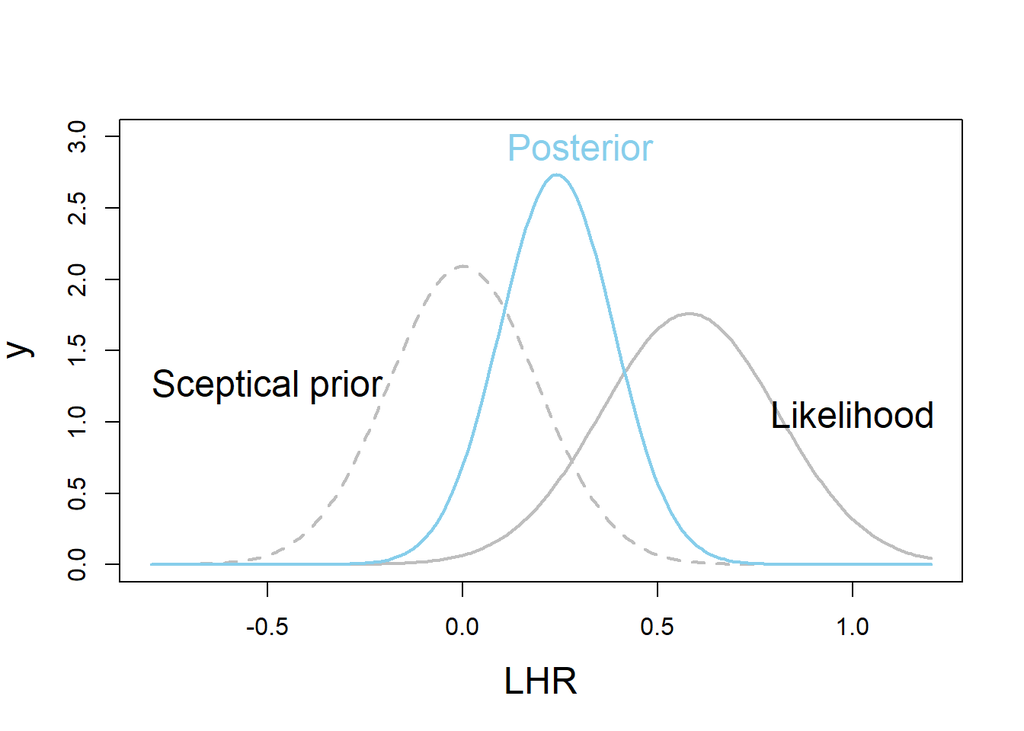

```r
x = seq(-0.8, 1.2, 0.01)
y = dnorm(x, mean = 0, sd = 0.1907)
Likelihood = dnorm(x, mean = 0.58, sd = 0.2266)
h=function(x){dnorm(x, mean = 0, sd = 0.1907)*dnorm(x, mean = 0.58, sd = 0.2266)}
c = integrate(h,-0.8, 1.2)
Posterior = y*Likelihood/c$value
plot(x, y, type = "l", col = "gray",
     lty = 2, xlab="LHR", cex.lab=1.5, cex.main=1.5,
     ylim = c(0,3), xlim = c(-0.8,1.2),
     lwd=2)
text(-0.5, .6*max(y) , "Sceptical prior", cex=1.5 )
lines(x, Likelihood, type = "l", col = "gray",
     lty = 1,  cex.lab=1.5,
     cex.main=1.5, lwd=2)
text(1.0, .6*max(Likelihood) , "Likelihood", cex=1.5 )
lines(x, Posterior, type = "l", col = "skyblue",
     lty = 1,  cex.lab=1.5,
     cex.main=1.5, lwd=2)
text(0.3, max(Posterior) +0.2, "Posterior", col = "skyblue",
     cex=1.5 )
```

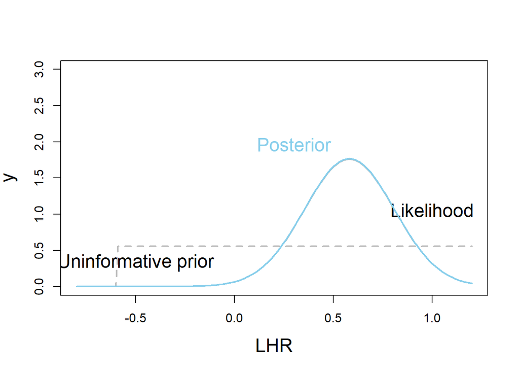

```r
x = seq(-0.8, 1.2, 0.01)
y = dunif(x, min = -0.6, max = 1.2)
Likelihood = dnorm(x, mean = 0.58, sd = 0.2266)
h=function(x){dunif(x, min = -0.6, max = 1.2)*dnorm(x, mean = 0.58, sd = 0.2266)}
c = integrate(h,-0.8, 1.2)
Posterior = y*Likelihood/c$value
plot(x, y, type = "l", col = "gray",
     lty = 2, xlab="LHR", cex.lab=1.5, cex.main=1.5,
     ylim = c(0,3), xlim = c(-0.8,1.2),
     lwd=2)
text(-0.5, .6*max(y) , "Uninformative prior", cex=1.5 )
lines(x, Likelihood, type = "l", col = "gray",
     lty = 1,  cex.lab=1.5,
     cex.main=1.5, lwd=2)
text(1.0, .6*max(Likelihood) , "Likelihood", cex=1.5 )
lines(x, Posterior, type = "l", col = "skyblue",
     lty = 1,  cex.lab=1.5,
     cex.main=1.5, lwd=2)
text(0.3, max(Posterior) +0.2, "Posterior", col = "skyblue",
     cex=1.5 )
```

```r
x = seq(-0.8, 1.2, 0.01)
y = dnorm(x, mean = 0, sd = 0.1907)
Likelihood = dnorm(x, mean = 0.58, sd = 0.2266)
h=function(x){dnorm(x, mean = 0, sd = 0.1907)*dnorm(x, mean = 0.58, sd = 0.2266)}
c = integrate(h,-0.8, 1.2)

Posterior_f = function(x){dnorm(x, mean = 0, sd = 0.1907)*dnorm(x, mean = 0.58, sd = 0.2266)/c$value}

#The mean
x[Posterior_f(x) == max(Posterior_f(x))]
```

```
## [1] 0.24
```

```r
sum(Posterior_f(x)*x*0.01)
```

```
## [1] 0.24
```

```r
#The probability that improvement is greater than 10% corresponding to LHR = 0.3137)
x2 = seq(0.3137, 1.2, 0.01)
sum(Posterior_f(x2)*0.01)
```

```
## [1] 0.32
```

```r
qbeta(0.025,shape1=1, shape2=92)
```

```
## [1] 0.000275
```

```r
qbeta(0.975,shape1=1, shape2=92)
```

```
## [1] 0.0393
```

```r
#Exercises 12.1
library(tidyverse)
data1 <- tibble(theta = c(seq(0,1.0, 0.1)),
       Hypothesis=c(rep('H0', 6),rep('H1', 5))) |> mutate(
          Prior = c(rep(0.5/6, 6),rep(0.5/5,5)),
          Likelihood = choose(10,5)*theta^5*(1-theta)^5,
          LikelihoodXPrior= Prior*Likelihood,
          Posterior = LikelihoodXPrior/sum(LikelihoodXPrior)
)
data1
```

```
## # A tibble: 11 × 6
##    theta Hypothesis  Prior Likelihood LikelihoodXPrior Posterior
##    <dbl> <chr>       <dbl>      <dbl>            <dbl>     <dbl>
##  1   0   H0         0.0833    0               0          0
##  2   0.1 H0         0.0833    0.00149         0.000124   0.00153
##  3   0.2 H0         0.0833    0.0264          0.00220    0.0271
##  4   0.3 H0         0.0833    0.103           0.00858    0.106
##  5   0.4 H0         0.0833    0.201           0.0167     0.206
##  6   0.5 H0         0.0833    0.246           0.0205     0.252
##  7   0.6 H1         0.1       0.201           0.0201     0.247
##  8   0.7 H1         0.1       0.103           0.0103     0.127
##  9   0.8 H1         0.1       0.0264          0.00264    0.0325
## 10   0.9 H1         0.1       0.00149         0.000149   0.00183
## 11   1   H1         0.1       0               0          0
```

```r
sum(data1$Posterior[data1$theta>0.5])
```

```
## [1] 0.408
```

```r
data1 <- tibble(theta = c(seq(0,1.0, 0.1)),
       Hypothesis=c(rep('H0', 6),rep('H1', 5))) |> mutate(
          Prior = c(rep(0.5/6, 6),rep(0.5/5,5)),
          Likelihood = choose(10,1)*theta^1*(1-theta)^9,
          LikelihoodXPrior= Prior*Likelihood,
          Posterior = LikelihoodXPrior/sum(LikelihoodXPrior)
)
data1
```

```
## # A tibble: 11 × 6
##    theta Hypothesis  Prior    Likelihood LikelihoodXPrior    Posterior
##    <dbl> <chr>       <dbl>         <dbl>            <dbl>        <dbl>
##  1   0   H0         0.0833 0                     0        0
##  2   0.1 H0         0.0833 0.387                 3.23e- 2 0.467
##  3   0.2 H0         0.0833 0.268                 2.24e- 2 0.324
##  4   0.3 H0         0.0833 0.121                 1.01e- 2 0.146
##  5   0.4 H0         0.0833 0.0403                3.36e- 3 0.0486
##  6   0.5 H0         0.0833 0.00977               8.14e- 4 0.0118
##  7   0.6 H1         0.1    0.00157               1.57e- 4 0.00228
##  8   0.7 H1         0.1    0.000138              1.38e- 5 0.000199
##  9   0.8 H1         0.1    0.00000410            4.10e- 7 0.00000593
## 10   0.9 H1         0.1    0.00000000900         9.00e-10 0.0000000130
## 11   1   H1         0.1    0                     0        0
```

```r
sum(data1$Posterior[data1$theta>0.5])
```

```
## [1] 0.00248
```

```r
data1 <- tibble(theta = c(seq(0,1.0, 0.1)),
       Hypothesis=c(rep('H0', 6),rep('H1', 5))) |> mutate(
          Prior = c(rep(0.01/6, 6),rep(0.99/5,5)),
          Likelihood = choose(10,5)*theta^5*(1-theta)^5,
          LikelihoodXPrior= Prior*Likelihood,
          Posterior = LikelihoodXPrior/sum(LikelihoodXPrior)
)
data1
```

```
## # A tibble: 11 × 6
##    theta Hypothesis   Prior Likelihood LikelihoodXPrior Posterior
##    <dbl> <chr>        <dbl>      <dbl>            <dbl>     <dbl>
##  1   0   H0         0.00167    0             0          0
##  2   0.1 H0         0.00167    0.00149       0.00000248 0.0000372
##  3   0.2 H0         0.00167    0.0264        0.0000440  0.000661
##  4   0.3 H0         0.00167    0.103         0.000172   0.00258
##  5   0.4 H0         0.00167    0.201         0.000334   0.00502
##  6   0.5 H0         0.00167    0.246         0.000410   0.00616
##  7   0.6 H1         0.198      0.201         0.0397     0.597
##  8   0.7 H1         0.198      0.103         0.0204     0.306
##  9   0.8 H1         0.198      0.0264        0.00523    0.0786
## 10   0.9 H1         0.198      0.00149       0.000295   0.00442
## 11   1   H1         0.198      0             0          0
```

```r
sum(data1$Posterior[data1$theta>0.5])
```

```
## [1] 0.986
```

```r
data1 <- tibble(theta = c(seq(0,1.0, 0.1)),
       Hypothesis=c(rep('H0', 6),rep('H1', 5))) |> mutate(
          Prior = c(rep(0.01/6, 6),rep(0.99/5,5)),
          Likelihood = choose(10,1)*theta^1*(1-theta)^9,
          LikelihoodXPrior= Prior*Likelihood,
          Posterior = LikelihoodXPrior/sum(LikelihoodXPrior)
)
data1
```

```
## # A tibble: 11 × 6
##    theta Hypothesis   Prior    Likelihood LikelihoodXPrior  Posterior
##    <dbl> <chr>        <dbl>         <dbl>            <dbl>      <dbl>
##  1   0   H0         0.00167 0                0             0
##  2   0.1 H0         0.00167 0.387            0.000646      0.376
##  3   0.2 H0         0.00167 0.268            0.000447      0.260
##  4   0.3 H0         0.00167 0.121            0.000202      0.117
##  5   0.4 H0         0.00167 0.0403           0.0000672     0.0391
##  6   0.5 H0         0.00167 0.00977          0.0000163     0.00947
##  7   0.6 H1         0.198   0.00157          0.000311      0.181
##  8   0.7 H1         0.198   0.000138         0.0000273     0.0159
##  9   0.8 H1         0.198   0.00000410       0.000000811   0.000472
## 10   0.9 H1         0.198   0.00000000900    0.00000000178 0.00000104
## 11   1   H1         0.198   0                0             0
```

```r
sum(data1$Posterior[data1$theta>0.5])
```

```
## [1] 0.198
```

```r
library(Bolstad)
theta.space<-(0:10)/10
theta.mass<-c(rep(0.5/6,6),rep(0.5/5,5))
post<-binodp(5,10,pi=theta.space,pi.prior=theta.mass,ret=TRUE)
```

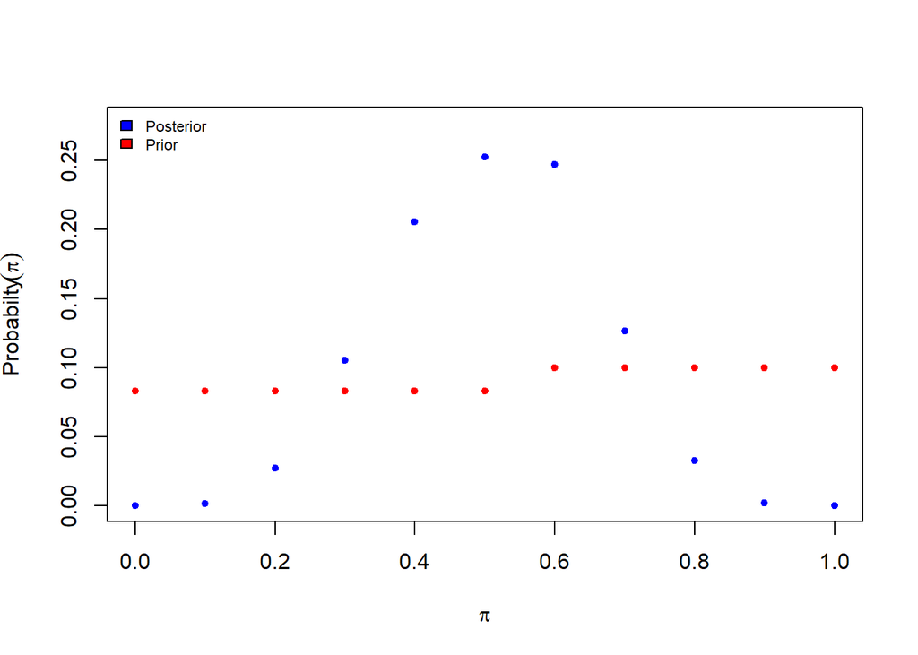

```
## Conditional distribution of x given pi and  n:
##
##          0      1      2      3      4      5      6      7      8      9
## 0   1.0000 0.0000 0.0000 0.0000 0.0000 0.0000 0.0000 0.0000 0.0000 0.0000
## 0.1 0.3487 0.3874 0.1937 0.0574 0.0112 0.0015 0.0001 0.0000 0.0000 0.0000
## 0.2 0.1074 0.2684 0.3020 0.2013 0.0881 0.0264 0.0055 0.0008 0.0001 0.0000
## 0.3 0.0282 0.1211 0.2335 0.2668 0.2001 0.1029 0.0368 0.0090 0.0014 0.0001
## 0.4 0.0060 0.0403 0.1209 0.2150 0.2508 0.2007 0.1115 0.0425 0.0106 0.0016
## 0.5 0.0010 0.0098 0.0439 0.1172 0.2051 0.2461 0.2051 0.1172 0.0439 0.0098
## 0.6 0.0001 0.0016 0.0106 0.0425 0.1115 0.2007 0.2508 0.2150 0.1209 0.0403
## 0.7 0.0000 0.0001 0.0014 0.0090 0.0368 0.1029 0.2001 0.2668 0.2335 0.1211
## 0.8 0.0000 0.0000 0.0001 0.0008 0.0055 0.0264 0.0881 0.2013 0.3020 0.2684
## 0.9 0.0000 0.0000 0.0000 0.0000 0.0001 0.0015 0.0112 0.0574 0.1937 0.3874
## 1   0.0000 0.0000 0.0000 0.0000 0.0000 0.0000 0.0000 0.0000 0.0000 0.0000
##         10
## 0   0.0000
## 0.1 0.0000
## 0.2 0.0000
## 0.3 0.0000
## 0.4 0.0001
## 0.5 0.0010
## 0.6 0.0060
## 0.7 0.0282
## 0.8 0.1074
## 0.9 0.3487
## 1   1.0000
##
## Joint distribution:
##
##            0      1      2      3      4      5      6      7      8      9
##  [1,] 0.0833 0.0000 0.0000 0.0000 0.0000 0.0000 0.0000 0.0000 0.0000 0.0000
##  [2,] 0.0291 0.0323 0.0161 0.0048 0.0009 0.0001 0.0000 0.0000 0.0000 0.0000
##  [3,] 0.0089 0.0224 0.0252 0.0168 0.0073 0.0022 0.0005 0.0001 0.0000 0.0000
##  [4,] 0.0024 0.0101 0.0195 0.0222 0.0167 0.0086 0.0031 0.0008 0.0001 0.0000
##  [5,] 0.0005 0.0034 0.0101 0.0179 0.0209 0.0167 0.0093 0.0035 0.0009 0.0001
##  [6,] 0.0001 0.0008 0.0037 0.0098 0.0171 0.0205 0.0171 0.0098 0.0037 0.0008
##  [7,] 0.0000 0.0002 0.0011 0.0042 0.0111 0.0201 0.0251 0.0215 0.0121 0.0040
##  [8,] 0.0000 0.0000 0.0001 0.0009 0.0037 0.0103 0.0200 0.0267 0.0233 0.0121
##  [9,] 0.0000 0.0000 0.0000 0.0001 0.0006 0.0026 0.0088 0.0201 0.0302 0.0268
## [10,] 0.0000 0.0000 0.0000 0.0000 0.0000 0.0001 0.0011 0.0057 0.0194 0.0387
```

[output cut: 17 more lines]

```
## [1,] 0.124 0.0691 0.0757 0.0767 0.0783 0.0813 0.0849 0.0882 0.0897 0.0827 0.149
##
##
##      Prior Likelihood Posterior
## 0   0.0833    0.00000   0.00000
## 0.1 0.0833    0.00149   0.00153
## 0.2 0.0833    0.02642   0.02709
## 0.3 0.0833    0.10292   0.10552
## 0.4 0.0833    0.20066   0.20572
## 0.5 0.0833    0.24609   0.25231
## 0.6 0.1000    0.20066   0.24687
## 0.7 0.1000    0.10292   0.12662
## 0.8 0.1000    0.02642   0.03251
## 0.9 0.1000    0.00149   0.00183
## 1   0.1000    0.00000   0.00000
```

```r
sum(post$posterior[7:11])
```

```
## [1] 0.408
```

```r
#Exercises 12.2
mean <- 0.3137
sigma <- 0.1907
prior_f <- function(theta) {1/(sigma*sqrt(2*base::pi))*exp(-(theta-mean)^2/(2*sigma^2))}
x = seq(-0.8, 1.2, 0.01)
#prior probability that the new treatment is effective
integrate(prior_f,0, 1.2)
```

```
## 0.95 with absolute error < 1.5e-06
```

```r
#posterior probability that the new treatment is effective
sigma2 <- 0.2266
mean2 <- 0.58
L_Prior <- function(theta) {1/(sigma2*sqrt(2*base::pi))*exp(-(theta-mean2)^2/(2*sigma2^2))*1/(sigma*sqrt(2*base::pi))*exp(-(theta-mean)^2/(2*sigma^2))}
c <- integrate(L_Prior, -1.2, 1.2)$value
posterior_f <- function(theta) {1/(sigma2*sqrt(2*base::pi))*exp(-(theta-mean2)^2/(2*sigma2^2))*1/(sigma*sqrt(2*base::pi))*exp(-(theta-mean)^2/(2*sigma^2))/c}
integrate(posterior_f, 0, 1.5)
```

```
## 0.998 with absolute error < 1.1e-09
```

## Chapter13 Markov Chain Monte Carlo Methods

```r
N=10000
x <- rnorm(N,mean=2,sd=1)+rnorm(N,mean=5,sd=0.5)
Fn <- ecdf(x)
Fn(4)
```

```
## [1] 0.0049
```

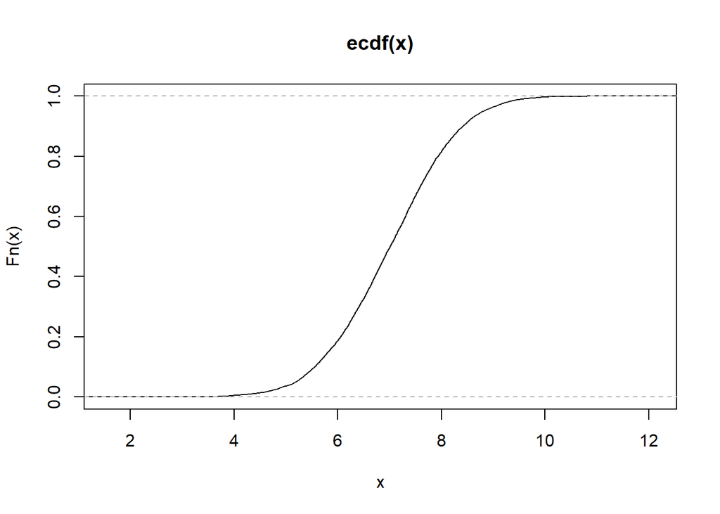

```r
plot(Fn, verticals = TRUE, do.points = FALSE)
```

```r
inverse = function (f, lower = -100, upper = 100) {
   function (y) uniroot((function (x) f(x) - y), lower = lower, upper = upper)[[1]]
}

ecdf_inverse = inverse(function (x) Fn(x), 0.1, 100)

ecdf_inverse(0.5)
```

```
## [1] 7.01
```

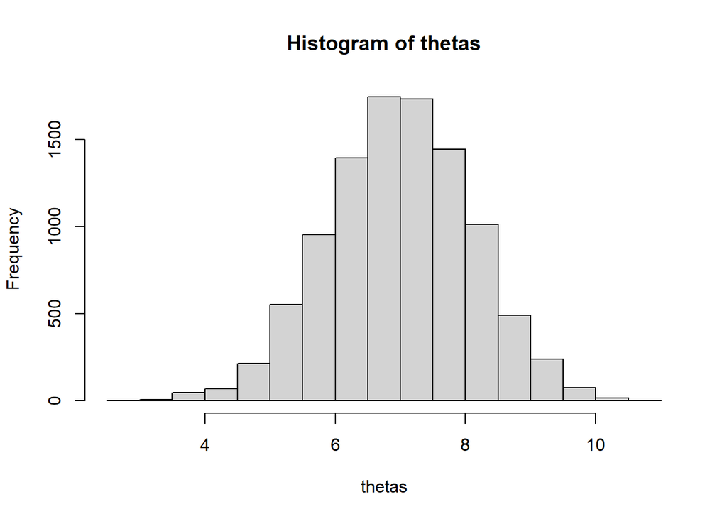

```r
u <- runif(N)
thetas <- sapply(u, ecdf_inverse)
hist(thetas)
```

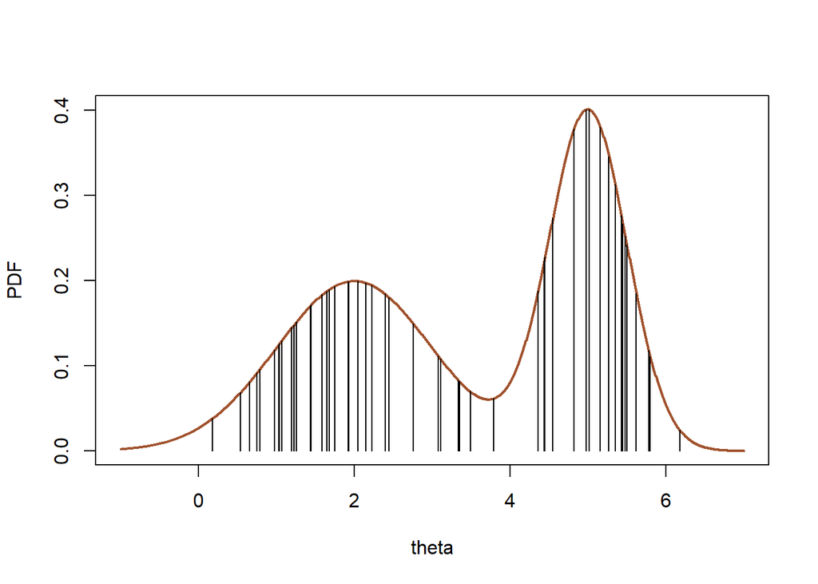

```r
library(tidyverse)
theta <- seq(-1,7,0.01)
d_theta = 0.5*dnorm(theta,mean=2,sd=1)+0.5*dnorm(theta,mean=5,sd=0.5)

curve(0.5*dnorm(x,mean=2,sd=1)+0.5*dnorm(x,mean=5,sd=0.5), -1, 7, col="sienna",
    lwd=2,n=1001, ylab="PDF", xlab="theta")
data = tibble('x'=theta, 'y'=d_theta)

data2 <- data[sample(seq_len(nrow(data)), 50, prob=data$y),]
segments(x0 = data2$x,
         y0 = 0,
         x1 = data2$x,
         y1 = data2$y,
         col= 'black',
         lwd = 1)
```

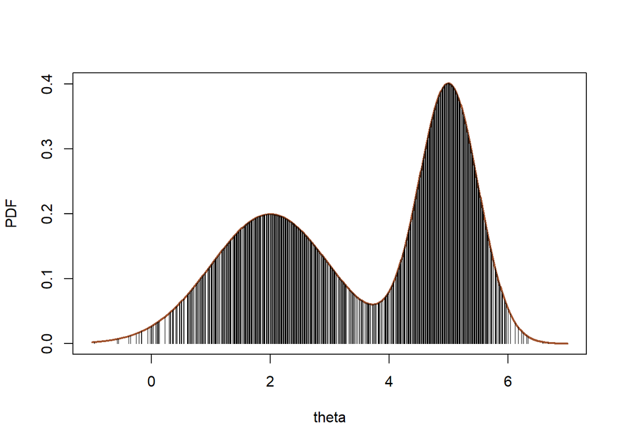

```r
theta <- seq(-1,7,0.01)
d_theta = 0.5*dnorm(theta,mean=2,sd=1)+0.5*dnorm(theta,mean=5,sd=0.5)

curve(0.5*dnorm(x,mean=2,sd=1)+0.5*dnorm(x,mean=5,sd=0.5), -1, 7, col="sienna",
    lwd=2,n=1001, ylab="PDF", xlab="theta") # plots the results

data = tibble('x'=theta, 'y'=d_theta)
data2 <- data[sample(seq_len(nrow(data)), 500, prob=data$y),]

segments(x0 = data2$x,
         y0 = 0,
         x1 = data2$x,
         y1 = data2$y,
         col= 'black',
         type="l",
         lwd = 0.1)
```

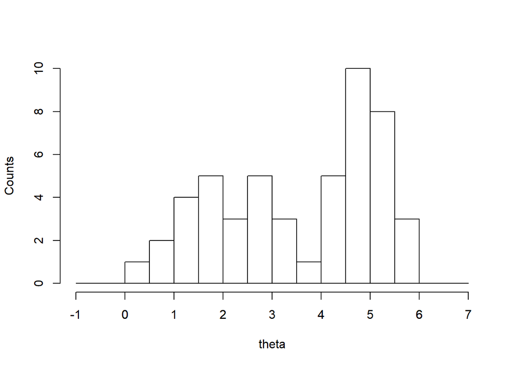

```r
data2 <- data[sample(seq_len(nrow(data)), 50, prob=data$y),]
hist(data2$x,
     breaks = seq(from=-1, to=7, by=0.5),
        main="",
        col="white",
        xlab="theta",
     ylab="Counts")
axis(side=1, at=seq(from=-1, to=7, by=1))
```

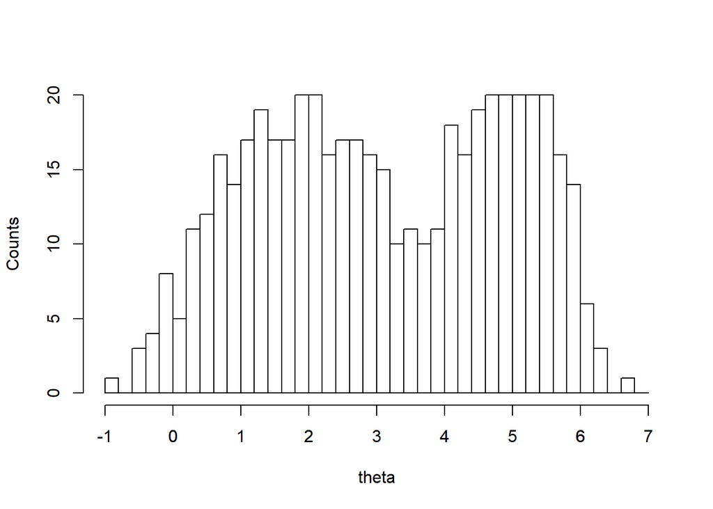

```r
data2 <- data[sample(seq_len(nrow(data)), 500, prob=data$y),]
hist(data2$x,
     breaks = seq(from=-1, to=7, by=0.2),
        main="",
        col="white",
        xlab="theta",
     ylab="Counts")
axis(side=1, at=seq(from=-1, to=7, by=1))
```

```r
data2 <- data[sample(seq_len(nrow(data)), 500, prob=data$y),]
#sample mean
weighted.mean(data2$x,data2$y)
```

```
## [1] 3.67
```

```r
weighted.mean(data$x,data$y)
```

```
## [1] 3.5
```

```r
#True mean
c <- integrate(\(x) (0.5*dnorm(x,mean=2,sd=1)+0.5*dnorm(x,mean=5,sd=0.5)), -10, 10)
density_x <- function(x){
  (dnorm(x,mean=2,sd=1)+dnorm(x,mean=5,sd=0.5))*x/c$value
}
integrate(density_x, -10, 10)$value
```

```
## [1] 7
```

```r
#True variance
c <- integrate(\(x) (dnorm(x,mean=2,sd=1)+dnorm(x,mean=5,sd=0.5)), -10, 10)
density_x_x <- function(x){
  (dnorm(x,mean=2,sd=1)+dnorm(x,mean=5,sd=0.5))*x*x/c$value
}
integrate(density_x_x, -10, 10)$value - (integrate(density_x, -10, 10)$value)^2
```

```
## [1] 2.87
```

```r
(2+5)*0.5
```

```
## [1] 3.5
```

```r
(1^2+(5-3.5)^2)*0.5+(0.5^2+(2-3.5)^2)*0.5
```

```
## [1] 2.88
```

```r
#sample median
data2 <- data[sample(seq_len(nrow(data)), 500, prob=data$y),]
quantile(data2$x, c(0.5))
```

```
##  50%
## 2.95
```

```r
#True median
for (i in 1:7) {
  if(abs(integrate(\(x) (0.5*dnorm(x,mean=2,sd=1)+0.5*dnorm(x,mean=5,sd=0.5)), -10, i)$value - 0.5)<0.001){
    print(i)
  }
}
```

```
## [1] 4
```

```r
y=c(6,13,18,28,52,53,61,60)
n=c(59,60,62,56,63,59,62,60)
x=c(1.6907,1.7242,1.7552,1.7842,1.8113,1.8369,1.8610,1.8839)
x_mean = x-mean(x)
n_y=n-y
beetle.mat=cbind(y,n_y)
beetle.mat
```

```
##       y n_y
## [1,]  6  53
## [2,] 13  47
## [3,] 18  44
## [4,] 28  28
## [5,] 52  11
## [6,] 53   6
## [7,] 61   1
## [8,] 60   0
```

```r
beetle
```

```
## # A tibble: 8 × 3
##       x     n     y
##   <dbl> <dbl> <dbl>
## 1  1.69    59     6
## 2  1.72    60    13
## 3  1.76    62    18
## 4  1.78    56    28
## 5  1.81    63    52
## 6  1.84    59    53
## 7  1.86    62    61
## 8  1.88    60    60
```

```r
res.glm1=glm(beetle.mat~x_mean, family=binomial(link="logit"))
res.glm1
```

```
##
## Call:  glm(formula = beetle.mat ~ x_mean, family = binomial(link = "logit"))
##
## Coefficients:
## (Intercept)       x_mean
##       0.744       34.270
##
## Degrees of Freedom: 7 Total (i.e. Null);  6 Residual
## Null Deviance:       284
## Residual Deviance: 11.2  AIC: 41.4
```

```r
logLik(res.glm1)
```

```
## 'log Lik.' -18.7 (df=2)
```

```r
#Extreme value model
res.glm3=glm(beetle.mat~x_mean, family=binomial(link="cloglog"))
res.glm3
```

```
##
## Call:  glm(formula = beetle.mat ~ x_mean, family = binomial(link = "cloglog"))
##
## Coefficients:
## (Intercept)       x_mean
##     -0.0431      22.0412
##
## Degrees of Freedom: 7 Total (i.e. Null);  6 Residual
## Null Deviance:       284
## Residual Deviance: 3.45  AIC: 33.6
```

```r
logLik(res.glm3)
```

```
## 'log Lik.' -14.8 (df=2)
```

```r
beta_1 = 0.7438
beta_2 = seq(20,40, 0.2)
mean_x = mean(x)
#pi = exp(beta_1 + beta_2*(x-mean_x))/(1+exp(beta_1 + beta_2*(x-mean_x)))
#pi/(1-pi) = (exp(beta_1 + beta_2*(x-mean_x))/(1+exp(beta_1 + beta_2*(x-mean_x))))/(1/(1+exp(beta_1 + beta_2*(x-mean_x))))
#log(pi/(1-pi)) = beta_1 + beta_2*(x-mean_x)
loglh <- function(beta2){
  sum(y*(beta_1+beta2*x_mean)+n*log(1/(1+exp(beta_1+beta2*x_mean)))+log(choose(n, y)))
}

lh_beta2 = sapply(beta_2, loglh)
lh_beta2
```

```
##   [1] -36.2 -35.7 -35.1 -34.6 -34.1 -33.6 -33.1 -32.6 -32.1 -31.6 -31.2 -30.7
##  [13] -30.3 -29.8 -29.4 -29.0 -28.6 -28.2 -27.8 -27.5 -27.1 -26.8 -26.4 -26.1
##  [25] -25.7 -25.4 -25.1 -24.8 -24.5 -24.2 -24.0 -23.7 -23.4 -23.2 -22.9 -22.7
##  [37] -22.5 -22.2 -22.0 -21.8 -21.6 -21.4 -21.2 -21.1 -20.9 -20.7 -20.6 -20.4
##  [49] -20.3 -20.1 -20.0 -19.9 -19.8 -19.7 -19.6 -19.5 -19.4 -19.3 -19.2 -19.1
##  [61] -19.1 -19.0 -19.0 -18.9 -18.9 -18.8 -18.8 -18.8 -18.7 -18.7 -18.7 -18.7
##  [73] -18.7 -18.7 -18.7 -18.7 -18.8 -18.8 -18.8 -18.9 -18.9 -19.0 -19.0 -19.1
##  [85] -19.1 -19.2 -19.2 -19.3 -19.4 -19.5 -19.6 -19.7 -19.8 -19.9 -20.0 -20.1
##  [97] -20.2 -20.3 -20.4 -20.5 -20.7
```

```r
beta_1 = 0.7438
y=c(6,13,18,28,52,53,61,60)
n=c(59,60,62,56,63,59,62,60)
x=c(1.6907,1.7242,1.7552,1.7842,1.8113,1.8369,1.8610,1.8839)
x_mean = x-mean(x)
n_y=n-y
lh <- function(beta_2){
  prod(exp(y*(beta_1+beta_2*x_mean)+n*log(1/(1+exp(beta_1+beta_2*x_mean)))+log(choose(n, y))))
}


beta2 <- c()
beta2[1] <- 1
for (i in 1:1000) {
  beta2_star <- beta2[i]+rnorm(1)
  alpha <- min((lh(beta2_star)/lh(beta2[i])),1)
  u <- runif(1,min = 0, max = 1)
  beta2[i+1] <- ifelse(alpha>u, beta2_star, beta2[i])
}
```

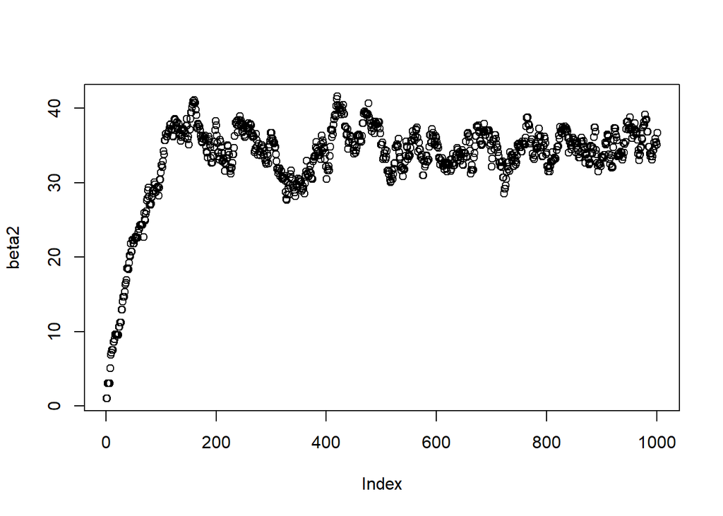

```r
plot(beta2)
```

## Chapter14 Example Bayesian Analyses

```r
#Extreme value model
res.glm3=glm(beetle.mat~x, family=binomial(link="cloglog"))
res.glm3
```

```
##
## Call:  glm(formula = beetle.mat ~ x, family = binomial(link = "cloglog"))
##
## Coefficients:
## (Intercept)            x
##       -39.6         22.0
##
## Degrees of Freedom: 7 Total (i.e. Null);  6 Residual
## Null Deviance:       284
## Residual Deviance: 3.45  AIC: 33.6
```

```r
logLik(res.glm3)
```

```
## 'log Lik.' -14.8 (df=2)
```

```r
res.glm3$deviance
```

```
## [1] 3.45
```

```r
#probit model
res.glm2=glm(beetle.mat~x, family=binomial(link="probit"))
res.glm2
```

```
##
## Call:  glm(formula = beetle.mat ~ x, family = binomial(link = "probit"))
##
## Coefficients:
## (Intercept)            x
##       -34.9         19.7
##
## Degrees of Freedom: 7 Total (i.e. Null);  6 Residual
## Null Deviance:       284
## Residual Deviance: 10.1  AIC: 40.3
```

```r
logLik(res.glm2)
```

```
## 'log Lik.' -18.2 (df=2)
```

```r
res.glm2$deviance
```

```
## [1] 10.1
```

```r
# manually calculating the quantile residual
library(statmod)
qresid(res.glm1)
```

```
## [1]  1.1460  1.2000 -1.0946 -1.5189  0.5640 -0.0897  1.0965  0.6564
```

Let $y_i$ is the proportion of the success and $\hat\mu_i$ is the fitted values of the model:

**Response**:
$$y_i -
\hat\mu_i$$
response residuals are inadequate for assessing a fitted glm, because GLMs are based on distributions where (in general) the variance depends on the mean.

**Pearson**:

The most direct way to handle the non-constant variance is to divide it out:
$$\frac{y_i -
\hat\mu_i}{\sqrt{V(\mu_i)|_{\hat\mu_i}}}$$
where $V()$ is the (GLM) variance function ($Var(y_i) = a(\phi)*V(\mu_i)$)

Under “Small dispersion asymptotics” conditions, the Pearson residuals have an approximate normal distribution.

**Deviance**:
$$sign(y_i-\hat\mu_i)*\sqrt{d_i}$$
where $d_i$ is the unit deviance, i.e.
$$d_i =
2(t(y_i,y_i)-t(y_i,\hat\mu_i))$$
For Deviance for a Poisson model:
$$sign(o_i-e_i)*\sqrt{d_i}=sign(o_i-e_i)*\sqrt{2[o_i\log(o_i/e_i)-(o_i-e_i)]},
\quad i=1,\dots,N$$

The deviance statistic (sum of squared unit-deviances) has an approximate chi-square distribution (when the saddlepoint approximation applies and under “Small dispersion asymptotics” conditions). Under these same conditions, the deviance **residuals** have an approximate normal distribution.

**Working**:
$$z_i - \eta_i$$
where $z_i$ are the working responses $\eta_i + \frac{d\eta_i}{d\mu_i}(y_i-\hat\mu_i)$ and $\eta_i$ is the linear predictor. Meaning you get that the residual is $\frac{d\eta_i}{d\mu_i}(y_i-\hat\mu_i)$.

The model coefficients are fitted using Fisher scoring algorithm / Iterative Reweighted Least Square (IRLS). And [it can be shown][1] that each iteration of this algorithm is equivalent to doing ordinary least-squares on the working responses as defined here.

To test the link function - plotting the linear predictor against the working **responses** should come out linear if the right link function was used.

**Partial**:
$$z_i - \eta_i +
X^*\beta$$

where $X^*$ is the centered $X$. Partial residuals can be used to determine if a covariate/predictor is on an inappropriate scale.

**Quantile**:
$$\Phi^{-1}(F(y_i))$$

Where $F(y_i)$ is the CDF of $y_i$, and $\Phi^{-1}$ is the quantile function of standard normal (inverse CDF). For discrete $y_i$’s you take $u \sim Unif(F(y_i-1), F(y_i))$ and $\Phi^{-1}(u)$.

Here is an example code to calculate these residuals:

```r
Y = c(0,0,0,0,1,1,1,1,1)
x1 = c(1,2,3,1,2,2,3,3,3)
x2 = c(1,0,0,1,0,0,0,0,0)

fit = glm(Y ~ x1 + x2, family = 'binomial')

lp = predict(fit)
mu = exp(lp)/(1+exp(lp))

# manually calculating the 1st response residual
resid(fit, type="response")[1]
```

```
##         1
## -8.65e-09
```

```r
Y[1] - mu[1]
```

```
##         1
## -8.65e-09
```

```r
# manually calculating the 1st pearson residual
resid(fit, type="pearson")[1]
```

```
##        1
## -9.3e-05
```

```r
(Y[1]-mu[1]) / sqrt(mu[1]*(1-mu[1]))
```

```
##        1
## -9.3e-05
```

```r
# manually calculating the 1st deviance residual
resid(fit, type="deviance")[1]
```

```
##         1
## -0.000132
```

```r
sqrt(-2*log(1-mu[1]))*sign(Y[1]-mu[1])
```

```
##         1
## -0.000132
```

```r
# manually calculating the 1st working residual
resid(fit, type="working")[1]
```

```
##  1
## -1
```

```r
(Y[1]-mu[1]) / (mu[1]*(1-mu[1]))
```

```
##  1
## -1
```

```r
# manually calculating the 1st partial residual
resid(fit, type="partial")[1,1]
```

```
## [1] -1.5
```

```r
(Y[1]-mu[1]) / (mu[1]*(1-mu[1])) + fit$coefficients[2]*(x1[1] - mean(x1))
```

```
##    1
## -1.5
```

```r
resid(fit, type="partial")[1,2]
```

```
## [1] -15.7
```

```r
(Y[1]-mu[1]) / (mu[1]*(1-mu[1])) + fit$coefficients[3]*(x2[1] - mean(x2))
```

```
##     1
## -15.7
```

```r
# manually calculating the 1st quantile residual
library(statmod)
qresid(fit)[1] # results are random (uniformly), so won't come the same
```

```
## [1] -1.58
```

```r
a = pbinom(Y[1]-1, 1, mu[1])
b = pbinom(Y[1], 1, mu[1])
qnorm(runif(1, a, b)) # results are random (uniformly), so won't come the same
```

```
## [1] -0.937
```

```r
n = 10000
mean(replicate(n, qresid(fit)[1]))
```

```
## [1] -0.00873
```

```r
mean(qnorm(runif(1000, a, b))) # should be close
```

```
## [1] -0.0332
```

reference:

[1]: https://stats.stackexchange.com/questions/1432/what-do-the-residuals-in-a-logistic-regression-mean/485734#485734